# APG analysis

#### Familiar X Trials

##### Condition Effect

###### Final Converging Model

The final model swith the maximal random effects structure that still allowed the models to converge.

Richter single-contrast approach.

```r
#Familiar X test
m <- glmer(isRight~conditionC+(1|participantCode),data=subset(d,exp=="exp2"&testType=="familiarX"),family=binomial,glmerControl(optimizer="bobyqa"))
summary(m)
```

```
## Generalized linear mixed model fit by maximum likelihood (Laplace
##   Approximation) [glmerMod]
##  Family: binomial  ( logit )
## Formula: isRight ~ conditionC + (1 | participantCode)
##    Data: subset(d, exp == "exp2" & testType == "familiarX")
## Control: glmerControl(optimizer = "bobyqa")
##
##      AIC      BIC   logLik deviance df.resid
##   5977.9   5997.0  -2985.9   5971.9     4371
##
## Scaled residuals:
##     Min      1Q  Median      3Q     Max
## -1.6370 -1.0474  0.6335  0.9101  1.2752
##
## Random effects:
##  Groups          Name        Variance Std.Dev.
##  participantCode (Intercept) 0.1683   0.4102
## Number of obs: 4374, groups:  participantCode, 243
##
## Fixed effects:
##             Estimate Std. Error z value Pr(>|z|)
## (Intercept)  0.21374    0.04078   5.241 1.59e-07 ***
## conditionC   0.23421    0.09982   2.346    0.019 *
## ---
## Signif. codes:  0 '***' 0.001 '**' 0.01 '*' 0.05 '.' 0.1 ' ' 1
##
## Correlation of Fixed Effects:
##            (Intr)
## conditionC -0.009
```

```r
confint(m, method="Wald")
```

```
##                  2.5 %    97.5 %
## .sig01              NA        NA
## (Intercept) 0.13381332 0.2936650
## conditionC  0.03856683 0.4298617
```

Abelson & Prentice approach.

```r
##check same analysis with Abelson & Prentice approach
m <- glmer(isRight~conditionC+conditionOrthContrast2+(1|participantCode),data=subset(d,exp=="exp2"&testType=="familiarX"),family=binomial,glmerControl(optimizer="bobyqa"))
summary(m)
```

```
## Generalized linear mixed model fit by maximum likelihood (Laplace
##   Approximation) [glmerMod]
##  Family: binomial  ( logit )
## Formula:
## isRight ~ conditionC + conditionOrthContrast2 + (1 | participantCode)
##    Data: subset(d, exp == "exp2" & testType == "familiarX")
## Control: glmerControl(optimizer = "bobyqa")
##
##      AIC      BIC   logLik deviance df.resid
##   5979.8   6005.4  -2985.9   5971.8     4370
##
## Scaled residuals:
##     Min      1Q  Median      3Q     Max
## -1.6399 -1.0491  0.6358  0.9085  1.2729
##
## Random effects:
##  Groups          Name        Variance Std.Dev.
##  participantCode (Intercept) 0.1682   0.4102
## Number of obs: 4374, groups:  participantCode, 243
##
## Fixed effects:
##                        Estimate Std. Error z value Pr(>|z|)
## (Intercept)             0.21375    0.04078   5.242 1.59e-07 ***
## conditionC              0.23405    0.09983   2.345    0.019 *
## conditionOrthContrast2 -0.01739    0.08627  -0.202    0.840
## ---
## Signif. codes:  0 '***' 0.001 '**' 0.01 '*' 0.05 '.' 0.1 ' ' 1
##
## Correlation of Fixed Effects:
##             (Intr) cndtnC
## conditionC  -0.009
## cndtnOrthC2 -0.002  0.008
```

###### Maximal Random Effects Model

Note that these models do not converge (singular fit), thus the parameter estimates should be interpreted with caution.

Richter single-contrast approach.

```r
#Familiar X test
m <- glmer(isRight~conditionC+(1|participantCode)+(1+conditionC|stimulus),data=subset(d,exp=="exp2"&testType=="familiarX"),family=binomial,glmerControl(optimizer="bobyqa"))
```

```
## boundary (singular) fit: see ?isSingular
```

```r
summary(m)
```

```
## Generalized linear mixed model fit by maximum likelihood (Laplace
##   Approximation) [glmerMod]
##  Family: binomial  ( logit )
## Formula: isRight ~ conditionC + (1 | participantCode) + (1 + conditionC |
##     stimulus)
##    Data: subset(d, exp == "exp2" & testType == "familiarX")
## Control: glmerControl(optimizer = "bobyqa")
##
##      AIC      BIC   logLik deviance df.resid
##   5983.9   6022.2  -2985.9   5971.9     4368
##
## Scaled residuals:
##     Min      1Q  Median      3Q     Max
## -1.6370 -1.0474  0.6335  0.9101  1.2752
##
## Random effects:
##  Groups          Name        Variance  Std.Dev.  Corr
##  participantCode (Intercept) 1.683e-01 4.102e-01
##  stimulus        (Intercept) 0.000e+00 0.000e+00
##                  conditionC  9.816e-13 9.908e-07  NaN
## Number of obs: 4374, groups:  participantCode, 243; stimulus, 18
##
## Fixed effects:
##             Estimate Std. Error z value Pr(>|z|)
## (Intercept)  0.21374    0.04078   5.241 1.59e-07 ***
## conditionC   0.23421    0.09983   2.346    0.019 *
## ---
## Signif. codes:  0 '***' 0.001 '**' 0.01 '*' 0.05 '.' 0.1 ' ' 1
##
## Correlation of Fixed Effects:
##            (Intr)
## conditionC -0.009
## convergence code: 0
## boundary (singular) fit: see ?isSingular
```

```r
confint(m, method="Wald")
```

```
##                  2.5 %    97.5 %
## .sig01              NA        NA
## .sig02              NA        NA
## .sig03              NA        NA
## .sig04              NA        NA
## (Intercept) 0.13381304 0.2936653
## conditionC  0.03855837 0.4298705
```

Abelson & Prentice approach.

```r
##check same analysis with Abelson & Prentice approach
m <- glmer(isRight~conditionC+conditionOrthContrast2+(1|participantCode)+(1+conditionC+conditionOrthContrast2|stimulus),data=subset(d,exp=="exp2"&testType=="familiarX"),family=binomial,glmerControl(optimizer="bobyqa"))
```

```
## boundary (singular) fit: see ?isSingular
```

```r
summary(m)
```

```
## Generalized linear mixed model fit by maximum likelihood (Laplace
##   Approximation) [glmerMod]
##  Family: binomial  ( logit )
## Formula:
## isRight ~ conditionC + conditionOrthContrast2 + (1 | participantCode) +
##     (1 + conditionC + conditionOrthContrast2 | stimulus)
##    Data: subset(d, exp == "exp2" & testType == "familiarX")
## Control: glmerControl(optimizer = "bobyqa")
##
##      AIC      BIC   logLik deviance df.resid
##   5991.4   6055.2  -2985.7   5971.4     4364
##
## Scaled residuals:
##     Min      1Q  Median      3Q     Max
## -1.6593 -1.0338  0.6264  0.9200  1.2700
##
## Random effects:
##  Groups          Name                   Variance Std.Dev. Corr
##  participantCode (Intercept)            0.168977 0.41107
##  stimulus        (Intercept)            0.000000 0.00000
##                  conditionC             0.006392 0.07995    NaN
##                  conditionOrthContrast2 0.013478 0.11610    NaN -1.00
## Number of obs: 4374, groups:  participantCode, 243; stimulus, 18
##
## Fixed effects:
##                        Estimate Std. Error z value Pr(>|z|)
## (Intercept)             0.21404    0.04083   5.242 1.59e-07 ***
## conditionC              0.23458    0.10171   2.306   0.0211 *
## conditionOrthContrast2 -0.01735    0.09062  -0.191   0.8481
## ---
## Signif. codes:  0 '***' 0.001 '**' 0.01 '*' 0.05 '.' 0.1 ' ' 1
##
## Correlation of Fixed Effects:
##             (Intr) cndtnC
## conditionC  -0.008
## cndtnOrthC2 -0.002 -0.049
## convergence code: 0
## boundary (singular) fit: see ?isSingular
```

##### Pairwise condition comparisons: Learnable vs. Non-Learnable Pre-Exposure

###### Final Converging Model

The final model with the maximal random effects structure that still allowed the model to converge.

```r
m <- glmer(isRight~conditionC+(1|participantCode),data=subset(d,exp=="exp2"&testType=="familiarX"&conditionC!=0),family=binomial,glmerControl(optimizer="bobyqa"))
summary(m)
```

```
## Generalized linear mixed model fit by maximum likelihood (Laplace
##   Approximation) [glmerMod]
##  Family: binomial  ( logit )
## Formula: isRight ~ conditionC + (1 | participantCode)
##    Data:
## subset(d, exp == "exp2" & testType == "familiarX" & conditionC !=      0)
## Control: glmerControl(optimizer = "bobyqa")
##
##      AIC      BIC   logLik deviance df.resid
##   3976.3   3994.2  -1985.1   3970.3     2913
##
## Scaled residuals:
##     Min      1Q  Median      3Q     Max
## -1.6929 -1.0392  0.5907  0.9135  1.3185
##
## Random effects:
##  Groups          Name        Variance Std.Dev.
##  participantCode (Intercept) 0.1952   0.4418
## Number of obs: 2916, groups:  participantCode, 162
##
## Fixed effects:
##             Estimate Std. Error z value Pr(>|z|)
## (Intercept)  0.22128    0.05171   4.280 1.87e-05 ***
## conditionC   0.23636    0.10330   2.288   0.0221 *
## ---
## Signif. codes:  0 '***' 0.001 '**' 0.01 '*' 0.05 '.' 0.1 ' ' 1
##
## Correlation of Fixed Effects:
##            (Intr)
## conditionC -0.010
```

```r
confint(m, method="Wald")[2:3,]
```

```
##                  2.5 %    97.5 %
## (Intercept) 0.11993445 0.3226191
## conditionC  0.03390341 0.4388136
```

###### Maximal Random Effects Model

Note that this model does not converge (singular fit), thus the parameter estimates should be interpreted with caution.

```r
#Learnable vs. Non-Learnable
m <- glmer(isRight~conditionC+(1|participantCode)+(1+conditionC|stimulus),data=subset(d,exp=="exp2"&testType=="familiarX"&conditionC!=0),family=binomial,glmerControl(optimizer="bobyqa"))
```

```
## boundary (singular) fit: see ?isSingular
```

```r
summary(m)
```

```
## Generalized linear mixed model fit by maximum likelihood (Laplace
##   Approximation) [glmerMod]
##  Family: binomial  ( logit )
## Formula: isRight ~ conditionC + (1 | participantCode) + (1 + conditionC |
##     stimulus)
##    Data:
## subset(d, exp == "exp2" & testType == "familiarX" & conditionC !=      0)
## Control: glmerControl(optimizer = "bobyqa")
##
##      AIC      BIC   logLik deviance df.resid
##   3982.1   4018.0  -1985.0   3970.1     2910
##
## Scaled residuals:
##     Min      1Q  Median      3Q     Max
## -1.7313 -1.0305  0.6027  0.9196  1.3325
##
## Random effects:
##  Groups          Name        Variance Std.Dev. Corr
##  participantCode (Intercept) 0.196003 0.44272
##  stimulus        (Intercept) 0.002680 0.05177
##                  conditionC  0.004735 0.06881  1.00
## Number of obs: 2916, groups:  participantCode, 162; stimulus, 18
##
## Fixed effects:
##             Estimate Std. Error z value Pr(>|z|)
## (Intercept)  0.22160    0.05319   4.166  3.1e-05 ***
## conditionC   0.23697    0.10470   2.263   0.0236 *
## ---
## Signif. codes:  0 '***' 0.001 '**' 0.01 '*' 0.05 '.' 0.1 ' ' 1
##
## Correlation of Fixed Effects:
##            (Intr)
## conditionC 0.026
## convergence code: 0
## boundary (singular) fit: see ?isSingular
```

```r
confint(m, method="Wald")[5:6,]
```

```
##                  2.5 %    97.5 %
## (Intercept) 0.11734423 0.3258622
## conditionC  0.03176701 0.4421646
```

##### Pairwise condition comparisons: No Pre-Exposure vs. Non-Learnable Pre-Exposure

###### Final Converging Model

The final model with the maximal random effects structure that still allowed the model to converge.

```r
#Non-Learnable vs. No Pre-Exposure
d$conditionNonLearnableNoPreExp <- ifelse(d$conditionC==0.5,1.5,
                                    ifelse(d$conditionC==0,0.5,d$conditionC))
m <- glmer(isRight~conditionNonLearnableNoPreExp+(1|participantCode),data=subset(d,exp=="exp2"&testType=="familiarX"&conditionNonLearnableNoPreExp!=1.5),family=binomial,glmerControl(optimizer="bobyqa"))
summary(m)
```

```
## Generalized linear mixed model fit by maximum likelihood (Laplace
##   Approximation) [glmerMod]
##  Family: binomial  ( logit )
## Formula: isRight ~ conditionNonLearnableNoPreExp + (1 | participantCode)
##    Data:
## subset(d, exp == "exp2" & testType == "familiarX" & conditionNonLearnableNoPreExp !=
##     1.5)
## Control: glmerControl(optimizer = "bobyqa")
##
##      AIC      BIC   logLik deviance df.resid
##   3978.9   3996.8  -1986.5   3972.9     2877
##
## Scaled residuals:
##     Min      1Q  Median      3Q     Max
## -1.2603 -1.0620  0.8258  0.9242  1.0339
##
## Random effects:
##  Groups          Name        Variance Std.Dev.
##  participantCode (Intercept) 0.04497  0.2121
## Number of obs: 2880, groups:  participantCode, 160
##
## Fixed effects:
##                               Estimate Std. Error z value Pr(>|z|)
## (Intercept)                    0.14732    0.04118   3.578 0.000347 ***
## conditionNonLearnableNoPreExp  0.09535    0.08232   1.158 0.246734
## ---
## Signif. codes:  0 '***' 0.001 '**' 0.01 '*' 0.05 '.' 0.1 ' ' 1
##
## Correlation of Fixed Effects:
##             (Intr)
## cndtnNnLNPE -0.009
```

```r
confint(m, method="Wald")[2:3,]
```

```
##                                     2.5 %    97.5 %
## (Intercept)                    0.06661052 0.2280203
## conditionNonLearnableNoPreExp -0.06599196 0.2566988
```

###### Maximal Random Effects Model

Note that this model does not converge (singular fit), thus the parameter estimates should be interpreted with caution.

```r
m <- glmer(isRight~conditionNonLearnableNoPreExp+(1|participantCode)+(1+conditionNonLearnableNoPreExp|stimulus),data=subset(d,exp=="exp2"&testType=="familiarX"&conditionNonLearnableNoPreExp!=1.5),family=binomial,glmerControl(optimizer="bobyqa"))
```

```
## boundary (singular) fit: see ?isSingular
```

```r
summary(m)
```

```
## Generalized linear mixed model fit by maximum likelihood (Laplace
##   Approximation) [glmerMod]
##  Family: binomial  ( logit )
## Formula:
## isRight ~ conditionNonLearnableNoPreExp + (1 | participantCode) +
##     (1 + conditionNonLearnableNoPreExp | stimulus)
##    Data:
## subset(d, exp == "exp2" & testType == "familiarX" & conditionNonLearnableNoPreExp !=
##     1.5)
## Control: glmerControl(optimizer = "bobyqa")
##
##      AIC      BIC   logLik deviance df.resid
##   3984.9   4020.7  -1986.5   3972.9     2874
##
## Scaled residuals:
##     Min      1Q  Median      3Q     Max
## -1.2603 -1.0620  0.8258  0.9242  1.0339
##
## Random effects:
##  Groups          Name                          Variance  Std.Dev.  Corr
##  participantCode (Intercept)                   4.497e-02 2.121e-01
##  stimulus        (Intercept)                   0.000e+00 0.000e+00
##                  conditionNonLearnableNoPreExp 8.318e-14 2.884e-07  NaN
## Number of obs: 2880, groups:  participantCode, 160; stimulus, 18
##
## Fixed effects:
##                               Estimate Std. Error z value Pr(>|z|)
## (Intercept)                    0.14732    0.04118   3.578 0.000347 ***
## conditionNonLearnableNoPreExp  0.09535    0.08232   1.158 0.246736
## ---
## Signif. codes:  0 '***' 0.001 '**' 0.01 '*' 0.05 '.' 0.1 ' ' 1
##
## Correlation of Fixed Effects:
##             (Intr)
## cndtnNnLNPE -0.009
## convergence code: 0
## boundary (singular) fit: see ?isSingular
```

```r
confint(m, method="Wald")[5:6,]
```

```
##                                     2.5 %    97.5 %
## (Intercept)                    0.06661060 0.2280204
## conditionNonLearnableNoPreExp -0.06599234 0.2566987
```

##### Learnable vs. No Pre-Exposure

###### Final Converging Model

The final model with the maximal random effects structure that still allowed the model to converge.

```r
#Learnable vs. No Pre-Exposure
d$conditionLearnableNoPreExp <- ifelse(d$conditionC==-0.5,-1.5,
                                    ifelse(d$conditionC==0,-0.5,d$conditionC))
m <- glmer(isRight~conditionLearnableNoPreExp+(1|participantCode)+(0+conditionLearnableNoPreExp|stimulus),data=subset(d,exp=="exp2"&testType=="familiarX"&conditionLearnableNoPreExp!=-1.5),family=binomial,glmerControl(optimizer="bobyqa"))
summary(m)
```

```
## Generalized linear mixed model fit by maximum likelihood (Laplace
##   Approximation) [glmerMod]
##  Family: binomial  ( logit )
## Formula: isRight ~ conditionLearnableNoPreExp + (1 | participantCode) +
##     (0 + conditionLearnableNoPreExp | stimulus)
##    Data:
## subset(d, exp == "exp2" & testType == "familiarX" & conditionLearnableNoPreExp !=
##     -1.5)
## Control: glmerControl(optimizer = "bobyqa")
##
##      AIC      BIC   logLik deviance df.resid
##   3994.1   4018.1  -1993.0   3986.1     2948
##
## Scaled residuals:
##     Min      1Q  Median      3Q     Max
## -1.8783 -1.0341  0.5433  0.8938  1.4495
##
## Random effects:
##  Groups          Name                       Variance Std.Dev.
##  participantCode (Intercept)                0.29097  0.5394
##  stimulus        conditionLearnableNoPreExp 0.02787  0.1670
## Number of obs: 2952, groups:  participantCode, 164; stimulus, 18
##
## Fixed effects:
##                            Estimate Std. Error z value Pr(>|z|)
## (Intercept)                 0.27937    0.05724   4.881 1.06e-06 ***
## conditionLearnableNoPreExp  0.14039    0.12069   1.163    0.245
## ---
## Signif. codes:  0 '***' 0.001 '**' 0.01 '*' 0.05 '.' 0.1 ' ' 1
##
## Correlation of Fixed Effects:
##             (Intr)
## cndtnLrnNPE -0.002
```

```r
confint(m, method="Wald")[3:4,]
```

```
##                                  2.5 %    97.5 %
## (Intercept)                 0.16719023 0.3915568
## conditionLearnableNoPreExp -0.09615829 0.3769318
```

###### Maximal Random Effects Model

Note that this model does not converge (singular fit), thus the parameter estimates should be interpreted with caution.

```r
#Learnable vs. No Pre-Exposure
m <- glmer(isRight~conditionLearnableNoPreExp+(1|participantCode)+(1+conditionLearnableNoPreExp|stimulus),data=subset(d,exp=="exp2"&testType=="familiarX"&conditionLearnableNoPreExp!=-1.5),family=binomial,glmerControl(optimizer="bobyqa"))
```

```
## boundary (singular) fit: see ?isSingular
```

```r
summary(m)
```

```
## Generalized linear mixed model fit by maximum likelihood (Laplace
##   Approximation) [glmerMod]
##  Family: binomial  ( logit )
## Formula: isRight ~ conditionLearnableNoPreExp + (1 | participantCode) +
##     (1 + conditionLearnableNoPreExp | stimulus)
##    Data:
## subset(d, exp == "exp2" & testType == "familiarX" & conditionLearnableNoPreExp !=
##     -1.5)
## Control: glmerControl(optimizer = "bobyqa")
##
##      AIC      BIC   logLik deviance df.resid
##   3998.1   4034.0  -1993.0   3986.1     2946
##
## Scaled residuals:
##     Min      1Q  Median      3Q     Max
## -1.8783 -1.0341  0.5433  0.8938  1.4495
##
## Random effects:
##  Groups          Name                       Variance Std.Dev. Corr
##  participantCode (Intercept)                0.29097  0.5394
##  stimulus        (Intercept)                0.00000  0.0000
##                  conditionLearnableNoPreExp 0.02787  0.1670    NaN
## Number of obs: 2952, groups:  participantCode, 164; stimulus, 18
##
## Fixed effects:
##                            Estimate Std. Error z value Pr(>|z|)
## (Intercept)                 0.27937    0.05723   4.881 1.05e-06 ***
## conditionLearnableNoPreExp  0.14039    0.12066   1.164    0.245
## ---
## Signif. codes:  0 '***' 0.001 '**' 0.01 '*' 0.05 '.' 0.1 ' ' 1
##
## Correlation of Fixed Effects:
##             (Intr)
## cndtnLrnNPE -0.002
## convergence code: 0
## boundary (singular) fit: see ?isSingular
```

```r
confint(m, method="Wald")[5:6,]
```

```
##                                  2.5 %    97.5 %
## (Intercept)                 0.16719848 0.3915488
## conditionLearnableNoPreExp -0.09609512 0.3768695
```

##### Testing against chance: Learnable Pre-Exposure

###### Final Converging Model

The final model with the maximal random effects structure that still allowed the model to converge.

```r
m <- glmer(isRight~1+(1|participantCode)+(1|stimulus),data=subset(d,exp=="exp2"&testType=="familiarX"&condition=="Learnable Pre-Exposure"),family=binomial,glmerControl(optimizer="bobyqa"))
summary(m)
```

```
## Generalized linear mixed model fit by maximum likelihood (Laplace
##   Approximation) [glmerMod]
##  Family: binomial  ( logit )
## Formula: isRight ~ 1 + (1 | participantCode) + (1 | stimulus)
##    Data: subset(d, exp == "exp2" & testType == "familiarX" & condition ==
##     "Learnable Pre-Exposure")
## Control: glmerControl(optimizer = "bobyqa")
##
##      AIC      BIC   logLik deviance df.resid
##   1983.4   1999.3   -988.7   1977.4     1491
##
## Scaled residuals:
##     Min      1Q  Median      3Q     Max
## -2.1794 -1.0002  0.4687  0.8565  1.6969
##
## Random effects:
##  Groups          Name        Variance Std.Dev.
##  participantCode (Intercept) 0.50348  0.7096
##  stimulus        (Intercept) 0.01017  0.1008
## Number of obs: 1494, groups:  participantCode, 83; stimulus, 18
##
## Fixed effects:
##             Estimate Std. Error z value Pr(>|z|)
## (Intercept)  0.36784    0.09913   3.711 0.000207 ***
## ---
## Signif. codes:  0 '***' 0.001 '**' 0.01 '*' 0.05 '.' 0.1 ' ' 1
```

```r
confint(m, method="Wald")[3,]
```

```
##     2.5 %    97.5 %
## 0.1735530 0.5621242
```

##### Testing against chance: No Pre-Exposure

###### Final Converging Model

The final model with the maximal random effects structure that still allowed the model to converge.

```r
m <- glmer(isRight~1+(1|participantCode),data=subset(d,exp=="exp2"&testType=="familiarX"&condition=="No Pre-Exposure"),family=binomial,glmerControl(optimizer="bobyqa"))
summary(m)
```

```
## Generalized linear mixed model fit by maximum likelihood (Laplace
##   Approximation) [glmerMod]
##  Family: binomial  ( logit )
## Formula: isRight ~ 1 + (1 | participantCode)
##    Data: subset(d, exp == "exp2" & testType == "familiarX" & condition ==
##     "No Pre-Exposure")
## Control: glmerControl(optimizer = "bobyqa")
##
##      AIC      BIC   logLik deviance df.resid
##   2004.7   2015.2  -1000.3   2000.7     1456
##
## Scaled residuals:
##     Min      1Q  Median      3Q     Max
## -1.4595 -1.0674  0.6852  0.9015  1.0512
##
## Random effects:
##  Groups          Name        Variance Std.Dev.
##  participantCode (Intercept) 0.1172   0.3424
## Number of obs: 1458, groups:  participantCode, 81
##
## Fixed effects:
##             Estimate Std. Error z value Pr(>|z|)
## (Intercept)  0.19919    0.06564   3.035  0.00241 **
## ---
## Signif. codes:  0 '***' 0.001 '**' 0.01 '*' 0.05 '.' 0.1 ' ' 1
```

```r
confint(m, method="Wald")[2,]
```

```
##      2.5 %     97.5 %
## 0.07053917 0.32783279
```

###### Maximal Random Effects Model

Note that this model does not converge (singular fit), thus the parameter estimates should be interpreted with caution.

```r
m <- glmer(isRight~1+(1|participantCode)+(1|stimulus),data=subset(d,exp=="exp2"&testType=="familiarX"&condition=="No Pre-Exposure"),family=binomial,glmerControl(optimizer="bobyqa"))
```

```
## boundary (singular) fit: see ?isSingular
```

```r
summary(m)
```

```
## Generalized linear mixed model fit by maximum likelihood (Laplace
##   Approximation) [glmerMod]
##  Family: binomial  ( logit )
## Formula: isRight ~ 1 + (1 | participantCode) + (1 | stimulus)
##    Data: subset(d, exp == "exp2" & testType == "familiarX" & condition ==
##     "No Pre-Exposure")
## Control: glmerControl(optimizer = "bobyqa")
##
##      AIC      BIC   logLik deviance df.resid
##   2006.7   2022.5  -1000.3   2000.7     1455
##
## Scaled residuals:
##     Min      1Q  Median      3Q     Max
## -1.4595 -1.0674  0.6852  0.9015  1.0512
##
## Random effects:
##  Groups          Name        Variance Std.Dev.
##  participantCode (Intercept) 0.1172   0.3424
##  stimulus        (Intercept) 0.0000   0.0000
## Number of obs: 1458, groups:  participantCode, 81; stimulus, 18
##
## Fixed effects:
##             Estimate Std. Error z value Pr(>|z|)
## (Intercept)  0.19919    0.06564   3.035  0.00241 **
## ---
## Signif. codes:  0 '***' 0.001 '**' 0.01 '*' 0.05 '.' 0.1 ' ' 1
## convergence code: 0
## boundary (singular) fit: see ?isSingular
```

```r
confint(m, method="Wald")[3,]
```

```
##      2.5 %     97.5 %
## 0.07053982 0.32783222
```

##### Testing against chance: Non-Learnable Pre-Exposure

###### Final Converging Model

The final model with the maximal random effects structure that still allowed the model to converge.

```r
m <- glm(isRight~1,data=subset(d,exp=="exp2"&testType=="familiarX"&condition=="Non-Learnable Pre-Exposure"),family=binomial)
summary(m)
```

```
##
## Call:
## glm(formula = isRight ~ 1, family = binomial, data = subset(d,
##     exp == "exp2" & testType == "familiarX" & condition == "Non-Learnable Pre-Exposure"))
##
## Deviance Residuals:
##    Min      1Q  Median      3Q     Max
## -1.220  -1.220   1.136   1.136   1.136
##
## Coefficients:
##             Estimate Std. Error z value Pr(>|z|)
## (Intercept)  0.09853    0.05310   1.856   0.0635 .
## ---
## Signif. codes:  0 '***' 0.001 '**' 0.01 '*' 0.05 '.' 0.1 ' ' 1
##
## (Dispersion parameter for binomial family taken to be 1)
##
##     Null deviance: 1967.9  on 1421  degrees of freedom
## Residual deviance: 1967.9  on 1421  degrees of freedom
## AIC: 1969.9
##
## Number of Fisher Scoring iterations: 3
```

```r
confint(m, method="Wald")
```

```
##        2.5 %       97.5 %
## -0.005479146  0.202722259
```

###### Maximal Random Effects Model

Note that this model does not converge (singular fit), thus the parameter estimates should be interpreted with caution.

```r
m <- glmer(isRight~1+(1|participantCode)+(1|stimulus),data=subset(d,exp=="exp2"&testType=="familiarX"&condition=="Non-Learnable Pre-Exposure"),family=binomial,glmerControl(optimizer="bobyqa"))
```

```
## boundary (singular) fit: see ?isSingular
```

```r
summary(m)
```

```
## Generalized linear mixed model fit by maximum likelihood (Laplace
##   Approximation) [glmerMod]
##  Family: binomial  ( logit )
## Formula: isRight ~ 1 + (1 | participantCode) + (1 | stimulus)
##    Data: subset(d, exp == "exp2" & testType == "familiarX" & condition ==
##     "Non-Learnable Pre-Exposure")
## Control: glmerControl(optimizer = "bobyqa")
##
##      AIC      BIC   logLik deviance df.resid
##   1973.9   1989.6   -983.9   1967.9     1419
##
## Scaled residuals:
##     Min      1Q  Median      3Q     Max
## -1.0505 -1.0505  0.9519  0.9519  0.9519
##
## Random effects:
##  Groups          Name        Variance Std.Dev.
##  participantCode (Intercept) 0        0
##  stimulus        (Intercept) 0        0
## Number of obs: 1422, groups:  participantCode, 79; stimulus, 18
##
## Fixed effects:
##             Estimate Std. Error z value Pr(>|z|)
## (Intercept)  0.09853    0.05310   1.856   0.0635 .
## ---
## Signif. codes:  0 '***' 0.001 '**' 0.01 '*' 0.05 '.' 0.1 ' ' 1
## convergence code: 0
## boundary (singular) fit: see ?isSingular
```

```r
confint(m, method="Wald")[3,]
```

```
##        2.5 %       97.5 %
## -0.005544124  0.202609200
```

#### Novel X Trials

##### Condition Effect

###### Final Converging Model

The final model swith the maximal random effects structure that still allowed the models to converge.

Richter single-contrast approach.

```r
#novel X test
m <- glmer(isRight~conditionC+(1|participantCode),data=subset(d,exp=="exp2"&testType=="novelX"),family=binomial,glmerControl(optimizer="bobyqa"))
summary(m)
```

```
## Generalized linear mixed model fit by maximum likelihood (Laplace
##   Approximation) [glmerMod]
##  Family: binomial  ( logit )
## Formula: isRight ~ conditionC + (1 | participantCode)
##    Data: subset(d, exp == "exp2" & testType == "novelX")
## Control: glmerControl(optimizer = "bobyqa")
##
##      AIC      BIC   logLik deviance df.resid
##   5985.5   6004.7  -2989.8   5979.5     4369
##
## Scaled residuals:
##     Min      1Q  Median      3Q     Max
## -1.6300 -1.0533  0.6135  0.9244  1.2478
##
## Random effects:
##  Groups          Name        Variance Std.Dev.
##  participantCode (Intercept) 0.1799   0.4242
## Number of obs: 4372, groups:  participantCode, 243
##
## Fixed effects:
##             Estimate Std. Error z value Pr(>|z|)
## (Intercept)  0.18786    0.04135   4.544 5.53e-06 ***
## conditionC   0.16734    0.10124   1.653   0.0984 .
## ---
## Signif. codes:  0 '***' 0.001 '**' 0.01 '*' 0.05 '.' 0.1 ' ' 1
##
## Correlation of Fixed Effects:
##            (Intr)
## conditionC -0.012
```

```r
confint(m, method="Wald")
```

```
##                   2.5 %    97.5 %
## .sig01               NA        NA
## (Intercept)  0.10682393 0.2689007
## conditionC  -0.03109545 0.3657677
```

Abelson & Prentice approach.

```r
##check same analysis with Abelson & Prentice approach
m <- glmer(isRight~conditionC+conditionOrthContrast2+(1|participantCode),data=subset(d,exp=="exp2"&testType=="novelX"),family=binomial,glmerControl(optimizer="bobyqa"))
summary(m)
```

```
## Generalized linear mixed model fit by maximum likelihood (Laplace
##   Approximation) [glmerMod]
##  Family: binomial  ( logit )
## Formula:
## isRight ~ conditionC + conditionOrthContrast2 + (1 | participantCode)
##    Data: subset(d, exp == "exp2" & testType == "novelX")
## Control: glmerControl(optimizer = "bobyqa")
##
##      AIC      BIC   logLik deviance df.resid
##   5987.5   6013.0  -2989.7   5979.5     4368
##
## Scaled residuals:
##     Min      1Q  Median      3Q     Max
## -1.6334 -1.0492  0.6122  0.9226  1.2451
##
## Random effects:
##  Groups          Name        Variance Std.Dev.
##  participantCode (Intercept) 0.1798   0.4241
## Number of obs: 4372, groups:  participantCode, 243
##
## Fixed effects:
##                        Estimate Std. Error z value Pr(>|z|)
## (Intercept)             0.18788    0.04134   4.544 5.51e-06 ***
## conditionC              0.16709    0.10125   1.650   0.0989 .
## conditionOrthContrast2 -0.02148    0.08750  -0.245   0.8061
## ---
## Signif. codes:  0 '***' 0.001 '**' 0.01 '*' 0.05 '.' 0.1 ' ' 1
##
## Correlation of Fixed Effects:
##             (Intr) cndtnC
## conditionC  -0.012
## cndtnOrthC2 -0.003  0.009
```

###### Maximal Random Effects Model

Note that these models do not converge (singular fit), thus the parameter estimates should be interpreted with caution.

Richter single-contrast approach.

```r
#novel X test
m <- glmer(isRight~conditionC+(1|participantCode)+(1+conditionC|stimulus),data=subset(d,exp=="exp2"&testType=="novelX"),family=binomial,glmerControl(optimizer="bobyqa"))
```

```
## boundary (singular) fit: see ?isSingular
```

```r
summary(m)
```

```
## Generalized linear mixed model fit by maximum likelihood (Laplace
##   Approximation) [glmerMod]
##  Family: binomial  ( logit )
## Formula: isRight ~ conditionC + (1 | participantCode) + (1 + conditionC |
##     stimulus)
##    Data: subset(d, exp == "exp2" & testType == "novelX")
## Control: glmerControl(optimizer = "bobyqa")
##
##      AIC      BIC   logLik deviance df.resid
##   5991.5   6029.8  -2989.8   5979.5     4366
##
## Scaled residuals:
##     Min      1Q  Median      3Q     Max
## -1.6300 -1.0533  0.6135  0.9244  1.2478
##
## Random effects:
##  Groups          Name        Variance  Std.Dev.  Corr
##  participantCode (Intercept) 1.799e-01 4.242e-01
##  stimulus        (Intercept) 7.604e-48 2.758e-24
##                  conditionC  4.796e-11 6.926e-06 1.00
## Number of obs: 4372, groups:  participantCode, 243; stimulus, 18
##
## Fixed effects:
##             Estimate Std. Error z value Pr(>|z|)
## (Intercept)  0.18786    0.04135   4.544 5.53e-06 ***
## conditionC   0.16734    0.10124   1.653   0.0984 .
## ---
## Signif. codes:  0 '***' 0.001 '**' 0.01 '*' 0.05 '.' 0.1 ' ' 1
##
## Correlation of Fixed Effects:
##            (Intr)
## conditionC -0.012
## convergence code: 0
## boundary (singular) fit: see ?isSingular
```

```r
confint(m, method="Wald")
```

```
##                   2.5 %    97.5 %
## .sig01               NA        NA
## .sig02               NA        NA
## .sig03               NA        NA
## .sig04               NA        NA
## (Intercept)  0.10682401 0.2689005
## conditionC  -0.03110048 0.3657719
```

Abelson & Prentice approach.

```r
##check same analysis with Abelson & Prentice approach
m <- glmer(isRight~conditionC+conditionOrthContrast2+(1|participantCode)+(1+conditionC+conditionOrthContrast2|stimulus),data=subset(d,exp=="exp2"&testType=="novelX"),family=binomial,glmerControl(optimizer="bobyqa"))
```

```
## boundary (singular) fit: see ?isSingular
```

```r
summary(m)
```

```
## Generalized linear mixed model fit by maximum likelihood (Laplace
##   Approximation) [glmerMod]
##  Family: binomial  ( logit )
## Formula:
## isRight ~ conditionC + conditionOrthContrast2 + (1 | participantCode) +
##     (1 + conditionC + conditionOrthContrast2 | stimulus)
##    Data: subset(d, exp == "exp2" & testType == "novelX")
## Control: glmerControl(optimizer = "bobyqa")
##
##      AIC      BIC   logLik deviance df.resid
##   5999.4   6063.3  -2989.7   5979.4     4362
##
## Scaled residuals:
##     Min      1Q  Median      3Q     Max
## -1.6110 -1.0469  0.6151  0.9186  1.2489
##
## Random effects:
##  Groups          Name                   Variance  Std.Dev. Corr
##  participantCode (Intercept)            1.800e-01 0.42431
##  stimulus        (Intercept)            3.249e-05 0.00570
##                  conditionC             4.784e-03 0.06916   1.00
##                  conditionOrthContrast2 8.576e-04 0.02928  -1.00 -1.00
## Number of obs: 4372, groups:  participantCode, 243; stimulus, 18
##
## Fixed effects:
##                        Estimate Std. Error z value Pr(>|z|)
## (Intercept)             0.18795    0.04138   4.542 5.57e-06 ***
## conditionC              0.16725    0.10259   1.630    0.103
## conditionOrthContrast2 -0.02156    0.08780  -0.246    0.806
## ---
## Signif. codes:  0 '***' 0.001 '**' 0.01 '*' 0.05 '.' 0.1 ' ' 1
##
## Correlation of Fixed Effects:
##             (Intr) cndtnC
## conditionC  -0.006
## cndtnOrthC2 -0.005 -0.003
## convergence code: 0
## boundary (singular) fit: see ?isSingular
```

##### Pairwise condition comparisons: Learnable vs. Non-Learnable Pre-Exposure

###### Final Converging Model

The final model with the maximal random effects structure that still allowed the model to converge.

```r
m <- glmer(isRight~conditionC+(1|participantCode),data=subset(d,exp=="exp2"&testType=="novelX"&conditionC!=0),family=binomial,glmerControl(optimizer="bobyqa"))
summary(m)
```

```
## Generalized linear mixed model fit by maximum likelihood (Laplace
##   Approximation) [glmerMod]
##  Family: binomial  ( logit )
## Formula: isRight ~ conditionC + (1 | participantCode)
##    Data: subset(d, exp == "exp2" & testType == "novelX" & conditionC !=
##     0)
## Control: glmerControl(optimizer = "bobyqa")
##
##      AIC      BIC   logLik deviance df.resid
##   3978.1   3996.0  -1986.0   3972.1     2911
##
## Scaled residuals:
##     Min      1Q  Median      3Q     Max
## -1.7107 -1.0286  0.5846  0.9198  1.2856
##
## Random effects:
##  Groups          Name        Variance Std.Dev.
##  participantCode (Intercept) 0.2208   0.4699
## Number of obs: 2914, groups:  participantCode, 162
##
## Fixed effects:
##             Estimate Std. Error z value Pr(>|z|)
## (Intercept)  0.19742    0.05324   3.708 0.000209 ***
## conditionC   0.17020    0.10638   1.600 0.109609
## ---
## Signif. codes:  0 '***' 0.001 '**' 0.01 '*' 0.05 '.' 0.1 ' ' 1
##
## Correlation of Fixed Effects:
##            (Intr)
## conditionC -0.014
```

```r
confint(m, method="Wald")[2:3,]
```

```
##                   2.5 %    97.5 %
## (Intercept)  0.09307004 0.3017737
## conditionC  -0.03829648 0.3786892
```

###### Maximal Random Effects Model

Note that this model does not converge (singular fit), thus the parameter estimates should be interpreted with caution.

```r
#Learnable vs. Non-Learnable
m <- glmer(isRight~conditionC+(1|participantCode)+(1+conditionC|stimulus),data=subset(d,exp=="exp2"&testType=="novelX"&conditionC!=0),family=binomial,glmerControl(optimizer="bobyqa"))
```

```
## boundary (singular) fit: see ?isSingular
```

```r
summary(m)
```

```
## Generalized linear mixed model fit by maximum likelihood (Laplace
##   Approximation) [glmerMod]
##  Family: binomial  ( logit )
## Formula: isRight ~ conditionC + (1 | participantCode) + (1 + conditionC |
##     stimulus)
##    Data: subset(d, exp == "exp2" & testType == "novelX" & conditionC !=
##     0)
## Control: glmerControl(optimizer = "bobyqa")
##
##      AIC      BIC   logLik deviance df.resid
##   3984.1   4020.0  -1986.0   3972.1     2908
##
## Scaled residuals:
##     Min      1Q  Median      3Q     Max
## -1.6985 -1.0278  0.5844  0.9194  1.2875
##
## Random effects:
##  Groups          Name        Variance  Std.Dev. Corr
##  participantCode (Intercept) 0.2209195 0.47002
##  stimulus        (Intercept) 0.0001521 0.01233
##                  conditionC  0.0022525 0.04746  1.00
## Number of obs: 2914, groups:  participantCode, 162; stimulus, 18
##
## Fixed effects:
##             Estimate Std. Error z value Pr(>|z|)
## (Intercept)  0.19747    0.05334   3.702 0.000214 ***
## conditionC   0.17028    0.10699   1.592 0.111487
## ---
## Signif. codes:  0 '***' 0.001 '**' 0.01 '*' 0.05 '.' 0.1 ' ' 1
##
## Correlation of Fixed Effects:
##            (Intr)
## conditionC -0.008
## convergence code: 0
## boundary (singular) fit: see ?isSingular
```

```r
confint(m, method="Wald")[5:6,]
```

```
##                   2.5 %    97.5 %
## (Intercept)  0.09293437 0.3020100
## conditionC  -0.03941817 0.3799848
```

##### Pairwise condition comparisons: No Pre-Exposure vs. Non-Learnable Pre-Exposure

###### Final Converging Model

The final model with the maximal random effects structure that still allowed the model to converge.

```r
#Non-Learnable vs. No Pre-Exposure
d$conditionNonLearnableNoPreExp <- ifelse(d$conditionC==0.5,1.5,
                                    ifelse(d$conditionC==0,0.5,d$conditionC))
m <- glmer(isRight~conditionNonLearnableNoPreExp+(1|participantCode),data=subset(d,exp=="exp2"&testType=="novelX"&conditionNonLearnableNoPreExp!=1.5),family=binomial,glmerControl(optimizer="bobyqa"))
summary(m)
```

```
## Generalized linear mixed model fit by maximum likelihood (Laplace
##   Approximation) [glmerMod]
##  Family: binomial  ( logit )
## Formula: isRight ~ conditionNonLearnableNoPreExp + (1 | participantCode)
##    Data:
## subset(d, exp == "exp2" & testType == "novelX" & conditionNonLearnableNoPreExp !=
##     1.5)
## Control: glmerControl(optimizer = "bobyqa")
##
##      AIC      BIC   logLik deviance df.resid
##   3977.8   3995.7  -1985.9   3971.8     2877
##
## Scaled residuals:
##     Min      1Q  Median      3Q     Max
## -1.3354 -1.0475  0.8108  0.9335  1.1046
##
## Random effects:
##  Groups          Name        Variance Std.Dev.
##  participantCode (Intercept) 0.07499  0.2739
## Number of obs: 2880, groups:  participantCode, 160
##
## Fixed effects:
##                               Estimate Std. Error z value Pr(>|z|)
## (Intercept)                    0.13873    0.04350   3.189  0.00143 **
## conditionNonLearnableNoPreExp  0.05942    0.08696   0.683  0.49446
## ---
## Signif. codes:  0 '***' 0.001 '**' 0.01 '*' 0.05 '.' 0.1 ' ' 1
##
## Correlation of Fixed Effects:
##             (Intr)
## cndtnNnLNPE -0.010
```

```r
confint(m, method="Wald")[2:3,]
```

```
##                                     2.5 %    97.5 %
## (Intercept)                    0.05346753 0.2239883
## conditionNonLearnableNoPreExp -0.11102859 0.2298610
```

###### Maximal Random Effects Model

Note that this model does not converge (singular fit), thus the parameter estimates should be interpreted with caution.

```r
m <- glmer(isRight~conditionNonLearnableNoPreExp+(1|participantCode)+(1+conditionNonLearnableNoPreExp|stimulus),data=subset(d,exp=="exp2"&testType=="novelX"&conditionNonLearnableNoPreExp!=1.5),family=binomial,glmerControl(optimizer="bobyqa"))
```

```
## boundary (singular) fit: see ?isSingular
```

```r
summary(m)
```

```
## Generalized linear mixed model fit by maximum likelihood (Laplace
##   Approximation) [glmerMod]
##  Family: binomial  ( logit )
## Formula:
## isRight ~ conditionNonLearnableNoPreExp + (1 | participantCode) +
##     (1 + conditionNonLearnableNoPreExp | stimulus)
##    Data:
## subset(d, exp == "exp2" & testType == "novelX" & conditionNonLearnableNoPreExp !=
##     1.5)
## Control: glmerControl(optimizer = "bobyqa")
##
##      AIC      BIC   logLik deviance df.resid
##   3983.8   4019.6  -1985.9   3971.8     2874
##
## Scaled residuals:
##     Min      1Q  Median      3Q     Max
## -1.3354 -1.0475  0.8108  0.9335  1.1046
##
## Random effects:
##  Groups          Name                          Variance  Std.Dev.  Corr
##  participantCode (Intercept)                   7.499e-02 2.739e-01
##  stimulus        (Intercept)                   0.000e+00 0.000e+00
##                  conditionNonLearnableNoPreExp 6.435e-13 8.022e-07  NaN
## Number of obs: 2880, groups:  participantCode, 160; stimulus, 18
##
## Fixed effects:
##                               Estimate Std. Error z value Pr(>|z|)
## (Intercept)                    0.13873    0.04350   3.189  0.00143 **
## conditionNonLearnableNoPreExp  0.05942    0.08697   0.683  0.49447
## ---
## Signif. codes:  0 '***' 0.001 '**' 0.01 '*' 0.05 '.' 0.1 ' ' 1
##
## Correlation of Fixed Effects:
##             (Intr)
## cndtnNnLNPE -0.010
## convergence code: 0
## boundary (singular) fit: see ?isSingular
```

```r
confint(m, method="Wald")[5:6,]
```

```
##                                     2.5 %    97.5 %
## (Intercept)                    0.05346743 0.2239885
## conditionNonLearnableNoPreExp -0.11103239 0.2298644
```

##### Learnable vs. No Pre-Exposure

###### Final Converging Model

The final model with the maximal random effects structure that still allowed the model to converge.

```r
#Learnable vs. No Pre-Exposure
d$conditionLearnableNoPreExp <- ifelse(d$conditionC==-0.5,-1.5,
                                    ifelse(d$conditionC==0,-0.5,d$conditionC))
m <- glmer(isRight~conditionLearnableNoPreExp+(1|participantCode),data=subset(d,exp=="exp2"&testType=="novelX"&conditionLearnableNoPreExp!=-1.5),family=binomial,glmerControl(optimizer="bobyqa"))
summary(m)
```

```
## Generalized linear mixed model fit by maximum likelihood (Laplace
##   Approximation) [glmerMod]
##  Family: binomial  ( logit )
## Formula: isRight ~ conditionLearnableNoPreExp + (1 | participantCode)
##    Data:
## subset(d, exp == "exp2" & testType == "novelX" & conditionLearnableNoPreExp !=
##     -1.5)
## Control: glmerControl(optimizer = "bobyqa")
##
##      AIC      BIC   logLik deviance df.resid
##   4012.6   4030.6  -2003.3   4006.6     2947
##
## Scaled residuals:
##     Min      1Q  Median      3Q     Max
## -1.7797 -1.0416  0.5391  0.9040  1.2670
##
## Random effects:
##  Groups          Name        Variance Std.Dev.
##  participantCode (Intercept) 0.2611   0.511
## Number of obs: 2950, groups:  participantCode, 164
##
## Fixed effects:
##                            Estimate Std. Error z value Pr(>|z|)
## (Intercept)                  0.2318     0.0554   4.184 2.86e-05 ***
## conditionLearnableNoPreExp   0.1090     0.1105   0.986    0.324
## ---
## Signif. codes:  0 '***' 0.001 '**' 0.01 '*' 0.05 '.' 0.1 ' ' 1
##
## Correlation of Fixed Effects:
##             (Intr)
## cndtnLrnNPE -0.003
```

```r
confint(m, method="Wald")
```

```
##                                 2.5 %    97.5 %
## .sig01                             NA        NA
## (Intercept)                 0.1232104 0.3403638
## conditionLearnableNoPreExp -0.1076433 0.3255717
```

###### Maximal Random Effects Model

Note that this model does not converge (singular fit), thus the parameter estimates should be interpreted with caution.

```r
#Learnable vs. No Pre-Exposure
m <- glmer(isRight~conditionLearnableNoPreExp+(1|participantCode)+(1+conditionLearnableNoPreExp|stimulus),data=subset(d,exp=="exp2"&testType=="novelX"&conditionLearnableNoPreExp!=-1.5),family=binomial,glmerControl(optimizer="bobyqa"))
```

```
## boundary (singular) fit: see ?isSingular
```

```r
summary(m)
```

```
## Generalized linear mixed model fit by maximum likelihood (Laplace
##   Approximation) [glmerMod]
##  Family: binomial  ( logit )
## Formula: isRight ~ conditionLearnableNoPreExp + (1 | participantCode) +
##     (1 + conditionLearnableNoPreExp | stimulus)
##    Data:
## subset(d, exp == "exp2" & testType == "novelX" & conditionLearnableNoPreExp !=
##     -1.5)
## Control: glmerControl(optimizer = "bobyqa")
##
##      AIC      BIC   logLik deviance df.resid
##   4018.6   4054.5  -2003.3   4006.6     2944
##
## Scaled residuals:
##     Min      1Q  Median      3Q     Max
## -1.7669 -1.0416  0.5390  0.9039  1.2767
##
## Random effects:
##  Groups          Name                       Variance Std.Dev. Corr
##  participantCode (Intercept)                0.261329 0.51120
##  stimulus        (Intercept)                0.000271 0.01646
##                  conditionLearnableNoPreExp 0.002611 0.05110  1.00
## Number of obs: 2950, groups:  participantCode, 164; stimulus, 18
##
## Fixed effects:
##                            Estimate Std. Error z value Pr(>|z|)
## (Intercept)                 0.23186    0.05555   4.174    3e-05 ***
## conditionLearnableNoPreExp  0.10908    0.11121   0.981    0.327
## ---
## Signif. codes:  0 '***' 0.001 '**' 0.01 '*' 0.05 '.' 0.1 ' ' 1
##
## Correlation of Fixed Effects:
##             (Intr)
## cndtnLrnNPE 0.004
## convergence code: 0
## boundary (singular) fit: see ?isSingular
```

```r
confint(m, method="Wald")[5:6,]
```

```
##                                 2.5 %   97.5 %
## (Intercept)                 0.1229754 0.340737
## conditionLearnableNoPreExp -0.1088836 0.327037
```

##### Testing against chance: Learnable Pre-Exposure

###### Final Converging Model

The final model with the maximal random effects structure that still allowed the model to converge.

```r
m <- glmer(isRight~1+(1|participantCode)+(1|stimulus),data=subset(d,exp=="exp2"&testType=="novelX"&condition=="Learnable Pre-Exposure"),family=binomial,glmerControl(optimizer="bobyqa"))
summary(m)
```

```
## Generalized linear mixed model fit by maximum likelihood (Laplace
##   Approximation) [glmerMod]
##  Family: binomial  ( logit )
## Formula: isRight ~ 1 + (1 | participantCode) + (1 | stimulus)
##    Data: subset(d, exp == "exp2" & testType == "novelX" & condition ==
##     "Learnable Pre-Exposure")
## Control: glmerControl(optimizer = "bobyqa")
##
##      AIC      BIC   logLik deviance df.resid
##   1999.2   2015.1   -996.6   1993.2     1489
##
## Scaled residuals:
##     Min      1Q  Median      3Q     Max
## -2.0315 -1.0447  0.4406  0.8819  1.4071
##
## Random effects:
##  Groups          Name        Variance Std.Dev.
##  participantCode (Intercept) 0.459444 0.67782
##  stimulus        (Intercept) 0.001974 0.04443
## Number of obs: 1492, groups:  participantCode, 83; stimulus, 18
##
## Fixed effects:
##             Estimate Std. Error z value Pr(>|z|)
## (Intercept)  0.30295    0.09367   3.234  0.00122 **
## ---
## Signif. codes:  0 '***' 0.001 '**' 0.01 '*' 0.05 '.' 0.1 ' ' 1
```

```r
confint(m, method="Wald")[3,]
```

```
##     2.5 %    97.5 %
## 0.1193661 0.4865296
```

##### Testing against chance: No Pre-Exposure

###### Final Converging Model

The final model with the maximal random effects structure that still allowed the model to converge.

```r
m <- glmer(isRight~1+(1|participantCode),data=subset(d,exp=="exp2"&testType=="novelX"&condition=="No Pre-Exposure"),family=binomial,glmerControl(optimizer="bobyqa"))
summary(m)
```

```
## Generalized linear mixed model fit by maximum likelihood (Laplace
##   Approximation) [glmerMod]
##  Family: binomial  ( logit )
## Formula: isRight ~ 1 + (1 | participantCode)
##    Data: subset(d, exp == "exp2" & testType == "novelX" & condition ==
##     "No Pre-Exposure")
## Control: glmerControl(optimizer = "bobyqa")
##
##      AIC      BIC   logLik deviance df.resid
##   2009.4   2020.0  -1002.7   2005.4     1456
##
## Scaled residuals:
##     Min      1Q  Median      3Q     Max
## -1.4130 -1.0596  0.7077  0.9109  1.0877
##
## Random effects:
##  Groups          Name        Variance Std.Dev.
##  participantCode (Intercept) 0.1042   0.3227
## Number of obs: 1458, groups:  participantCode, 81
##
## Fixed effects:
##             Estimate Std. Error z value Pr(>|z|)
## (Intercept)  0.16987    0.06424   2.644  0.00818 **
## ---
## Signif. codes:  0 '***' 0.001 '**' 0.01 '*' 0.05 '.' 0.1 ' ' 1
```

```r
confint(m, method="Wald")[2,]
```

```
##      2.5 %     97.5 %
## 0.04396547 0.29578076
```

###### Maximal Random Effects Model

Note that this model does not converge (singular fit), thus the parameter estimates should be interpreted with caution.

```r
m <- glmer(isRight~1+(1|participantCode)+(1|stimulus),data=subset(d,exp=="exp2"&testType=="novelX"&condition=="No Pre-Exposure"),family=binomial,glmerControl(optimizer="bobyqa"))
```

```
## boundary (singular) fit: see ?isSingular
```

```r
summary(m)
```

```
## Generalized linear mixed model fit by maximum likelihood (Laplace
##   Approximation) [glmerMod]
##  Family: binomial  ( logit )
## Formula: isRight ~ 1 + (1 | participantCode) + (1 | stimulus)
##    Data: subset(d, exp == "exp2" & testType == "novelX" & condition ==
##     "No Pre-Exposure")
## Control: glmerControl(optimizer = "bobyqa")
##
##      AIC      BIC   logLik deviance df.resid
##   2011.4   2027.3  -1002.7   2005.4     1455
##
## Scaled residuals:
##     Min      1Q  Median      3Q     Max
## -1.4130 -1.0596  0.7077  0.9109  1.0877
##
## Random effects:
##  Groups          Name        Variance  Std.Dev.
##  participantCode (Intercept) 1.042e-01 0.3227442
##  stimulus        (Intercept) 4.000e-14 0.0000002
## Number of obs: 1458, groups:  participantCode, 81; stimulus, 18
##
## Fixed effects:
##             Estimate Std. Error z value Pr(>|z|)
## (Intercept)  0.16987    0.06424   2.644  0.00818 **
## ---
## Signif. codes:  0 '***' 0.001 '**' 0.01 '*' 0.05 '.' 0.1 ' ' 1
## convergence code: 0
## boundary (singular) fit: see ?isSingular
```

```r
confint(m, method="Wald")[3,]
```

```
##      2.5 %     97.5 %
## 0.04396522 0.29578106
```

##### Testing against chance: Non-Learnable Pre-Exposure

###### Final Converging Model

The final model with the maximal random effects structure that still allowed the model to converge.

```r
m <- glmer(isRight~1+(1|participantCode),data=subset(d,exp=="exp2"&testType=="novelX"&condition=="Non-Learnable Pre-Exposure"),family=binomial,glmerControl(optimizer="bobyqa"))
summary(m)
```

```
## Generalized linear mixed model fit by maximum likelihood (Laplace
##   Approximation) [glmerMod]
##  Family: binomial  ( logit )
## Formula: isRight ~ 1 + (1 | participantCode)
##    Data: subset(d, exp == "exp2" & testType == "novelX" & condition ==
##     "Non-Learnable Pre-Exposure")
## Control: glmerControl(optimizer = "bobyqa")
##
##      AIC      BIC   logLik deviance df.resid
##   1969.7   1980.2   -982.9   1965.7     1420
##
## Scaled residuals:
##     Min      1Q  Median      3Q     Max
## -1.2242 -1.0456  0.8667  0.9378  1.0552
##
## Random effects:
##  Groups          Name        Variance Std.Dev.
##  participantCode (Intercept) 0.04776  0.2185
## Number of obs: 1422, groups:  participantCode, 79
##
## Fixed effects:
##             Estimate Std. Error z value Pr(>|z|)
## (Intercept)  0.10830    0.05883   1.841   0.0656 .
## ---
## Signif. codes:  0 '***' 0.001 '**' 0.01 '*' 0.05 '.' 0.1 ' ' 1
```

```r
confint(m, method="Wald")
```

```
##                   2.5 %    97.5 %
## .sig01               NA        NA
## (Intercept) -0.00700433 0.2235945
```

###### Maximal Random Effects Model

Note that this model does not converge (singular fit), thus the parameter estimates should be interpreted with caution.

```r
m <- glmer(isRight~1+(1|participantCode)+(1|stimulus),data=subset(d,exp=="exp2"&testType=="novelX"&condition=="Non-Learnable Pre-Exposure"),family=binomial,glmerControl(optimizer="bobyqa"))
```

```
## boundary (singular) fit: see ?isSingular
```

```r
summary(m)
```

```
## Generalized linear mixed model fit by maximum likelihood (Laplace
##   Approximation) [glmerMod]
##  Family: binomial  ( logit )
## Formula: isRight ~ 1 + (1 | participantCode) + (1 | stimulus)
##    Data: subset(d, exp == "exp2" & testType == "novelX" & condition ==
##     "Non-Learnable Pre-Exposure")
## Control: glmerControl(optimizer = "bobyqa")
##
##      AIC      BIC   logLik deviance df.resid
##   1971.7   1987.5   -982.9   1965.7     1419
##
## Scaled residuals:
##     Min      1Q  Median      3Q     Max
## -1.2242 -1.0456  0.8667  0.9378  1.0552
##
## Random effects:
##  Groups          Name        Variance  Std.Dev.
##  participantCode (Intercept) 4.776e-02 2.185e-01
##  stimulus        (Intercept) 2.467e-14 1.571e-07
## Number of obs: 1422, groups:  participantCode, 79; stimulus, 18
##
## Fixed effects:
##             Estimate Std. Error z value Pr(>|z|)
## (Intercept)  0.10830    0.05883   1.841   0.0656 .
## ---
## Signif. codes:  0 '***' 0.001 '**' 0.01 '*' 0.05 '.' 0.1 ' ' 1
## convergence code: 0
## boundary (singular) fit: see ?isSingular
```

```r
confint(m, method="Wald")[3,]
```

```
##        2.5 %       97.5 %
## -0.007004624  0.223595045
```

#### Interaction between test type and condition

##### Final Converging Model

The final model with the maximal random effects structure that still allowed the model to converge.

```r
#recode test type
d$testTypeC <- ifelse(d$testType=="novelX",0.5,
                    ifelse(d$testType=="familiarX",-0.5,NA))
##all data
m <- glmer(isRight~conditionC*testTypeC+(1|participantCode),data=subset(d,exp=="exp2"),family=binomial,glmerControl(optimizer="bobyqa"))
summary(m)
```

```
## Generalized linear mixed model fit by maximum likelihood (Laplace
##   Approximation) [glmerMod]
##  Family: binomial  ( logit )
## Formula: isRight ~ conditionC * testTypeC + (1 | participantCode)
##    Data: subset(d, exp == "exp2")
## Control: glmerControl(optimizer = "bobyqa")
##
##      AIC      BIC   logLik deviance df.resid
##  11876.0  11911.4  -5933.0  11866.0     8741
##
## Scaled residuals:
##     Min      1Q  Median      3Q     Max
## -2.2135 -1.0274  0.4906  0.9289  1.3629
##
## Random effects:
##  Groups          Name        Variance Std.Dev.
##  participantCode (Intercept) 0.2358   0.4856
## Number of obs: 8746, groups:  participantCode, 243
##
## Fixed effects:
##                      Estimate Std. Error z value Pr(>|z|)
## (Intercept)           0.21043    0.03831   5.493 3.94e-08 ***
## conditionC            0.21653    0.09373   2.310   0.0209 *
## testTypeC            -0.02662    0.04404  -0.604   0.5455
## conditionC:testTypeC -0.06837    0.10798  -0.633   0.5266
## ---
## Signif. codes:  0 '***' 0.001 '**' 0.01 '*' 0.05 '.' 0.1 ' ' 1
##
## Correlation of Fixed Effects:
##             (Intr) cndtnC tstTyC
## conditionC  -0.008
## testTypeC   -0.001 -0.001
## cndtnC:tsTC -0.001 -0.001  0.000
```

```r
confint(m, method="Wald")
```

```
##                            2.5 %    97.5 %
## .sig01                        NA        NA
## (Intercept)           0.13534795 0.2855030
## conditionC            0.03283099 0.4002266
## testTypeC            -0.11292590 0.0596914
## conditionC:testTypeC -0.28001687 0.1432687
```

##### Maximal Random Effects Model

Note that this model does not converge (singular fit), thus the parameter estimates should be interpreted with caution.

```r
##all data
m <- glmer(isRight~conditionC*testTypeC+(1+testTypeC|participantCode)+(1+conditionC|stimulus),data=subset(d,exp=="exp2"),family=binomial,glmerControl(optimizer="bobyqa"))
```

```
## boundary (singular) fit: see ?isSingular
```

```r
summary(m)
```

```
## Generalized linear mixed model fit by maximum likelihood (Laplace
##   Approximation) [glmerMod]
##  Family: binomial  ( logit )
## Formula:
## isRight ~ conditionC * testTypeC + (1 + testTypeC | participantCode) +
##     (1 + conditionC | stimulus)
##    Data: subset(d, exp == "exp2")
## Control: glmerControl(optimizer = "bobyqa")
##
##      AIC      BIC   logLik deviance df.resid
##  11886.0  11956.7  -5933.0  11866.0     8736
##
## Scaled residuals:
##     Min      1Q  Median      3Q     Max
## -2.1980 -1.0278  0.4873  0.9287  1.3661
##
## Random effects:
##  Groups          Name        Variance  Std.Dev.  Corr
##  participantCode (Intercept) 2.358e-01 4.856e-01
##                  testTypeC   1.253e-04 1.119e-02 1.00
##  stimulus        (Intercept) 0.000e+00 0.000e+00
##                  conditionC  1.663e-11 4.079e-06  NaN
## Number of obs: 8746, groups:  participantCode, 243; stimulus, 36
##
## Fixed effects:
##                      Estimate Std. Error z value Pr(>|z|)
## (Intercept)           0.21041    0.03831   5.493 3.95e-08 ***
## conditionC            0.21650    0.09373   2.310   0.0209 *
## testTypeC            -0.02562    0.04436  -0.578   0.5635
## conditionC:testTypeC -0.06697    0.10828  -0.619   0.5362
## ---
## Signif. codes:  0 '***' 0.001 '**' 0.01 '*' 0.05 '.' 0.1 ' ' 1
##
## Correlation of Fixed Effects:
##             (Intr) cndtnC tstTyC
## conditionC  -0.008
## testTypeC    0.013 -0.001
## cndtnC:tsTC -0.001  0.013  0.008
## convergence code: 0
## boundary (singular) fit: see ?isSingular
```

```r
confint(m, method="Wald")[7:10,]
```

```
##                            2.5 %     97.5 %
## (Intercept)           0.13533088 0.28548410
## conditionC            0.03278973 0.40020560
## testTypeC            -0.11257745 0.06132889
## conditionC:testTypeC -0.27918889 0.14524766
```

### Signal Detection Analysis

#### Sensitivity

##### Overall

Richter single-contrast approach.

```r
#recode condition
subj_overall$conditionC <- ifelse(subj_overall$condition=="Learnable Pre-Exposure",0.5,
                    ifelse(subj_overall$condition=="Non-Learnable Pre-Exposure",-0.5,
                           ifelse(subj_overall$condition=="No Pre-Exposure",0,NA)))
subj_overall$conditionOrthContrast2 <- ifelse(subj_overall$condition=="Learnable Pre-Exposure",-1/3,
                                ifelse(subj_overall$condition=="Non-Learnable Pre-Exposure",-1/3,
                                       ifelse(subj_overall$condition=="No Pre-Exposure",2/3,NA)))

#overall analysis (Richter single-contrast apporach)
m <- lm(dprime~conditionC,data=subset(subj_overall,exp=="exp2"))
summary(m)
```

```
##
## Call:
## lm(formula = dprime ~ conditionC, data = subset(subj_overall,
##     exp == "exp2"))
##
## Residuals:
##     Min      1Q  Median      3Q     Max
## -1.8479 -0.4792 -0.1865  0.1336  3.5085
##
## Coefficients:
##             Estimate Std. Error t value Pr(>|t|)
## (Intercept)  0.32047    0.05898   5.433 1.35e-07 ***
## conditionC   0.34656    0.14448   2.399   0.0172 *
## ---
## Signif. codes:  0 '***' 0.001 '**' 0.01 '*' 0.05 '.' 0.1 ' ' 1
##
## Residual standard error: 0.9193 on 241 degrees of freedom
## Multiple R-squared:  0.02332,    Adjusted R-squared:  0.01926
## F-statistic: 5.754 on 1 and 241 DF,  p-value: 0.01722
```

Abelson & Prentice approach.

```r
##check same analysis with Abelson & Prentice approach
m <- lm(dprime~conditionC+conditionOrthContrast2,data=subset(subj_overall,exp=="exp2"))
summary(m)
```

```
##
## Call:
## lm(formula = dprime ~ conditionC + conditionOrthContrast2, data = subset(subj_overall,
##     exp == "exp2"))
##
## Residuals:
##     Min      1Q  Median      3Q     Max
## -1.8619 -0.4670 -0.2005  0.1346  3.5373
##
## Coefficients:
##                        Estimate Std. Error t value Pr(>|t|)
## (Intercept)             0.32048    0.05909   5.423 1.43e-07 ***
## conditionC              0.34585    0.14476   2.389   0.0177 *
## conditionOrthContrast2 -0.04310    0.12534  -0.344   0.7312
## ---
## Signif. codes:  0 '***' 0.001 '**' 0.01 '*' 0.05 '.' 0.1 ' ' 1
##
## Residual standard error: 0.921 on 240 degrees of freedom
## Multiple R-squared:  0.0238, Adjusted R-squared:  0.01566
## F-statistic: 2.925 on 2 and 240 DF,  p-value: 0.05556
```

###### Testing against chance: Learnable Pre-Exposure

```r
m <- lm(dprime~1,data=subset(subj_overall,exp=="exp2"&conditionC==0.5))
summary(m)
```

```
##
## Call:
## lm(formula = dprime ~ 1, data = subset(subj_overall, exp == "exp2" &
##     conditionC == 0.5))
##
## Residuals:
##     Min      1Q  Median      3Q     Max
## -1.8619 -0.6489 -0.3325 -0.0675  3.3212
##
## Coefficients:
##             Estimate Std. Error t value Pr(>|t|)
## (Intercept)   0.5078     0.1285   3.951 0.000164 ***
## ---
## Signif. codes:  0 '***' 0.001 '**' 0.01 '*' 0.05 '.' 0.1 ' ' 1
##
## Residual standard error: 1.171 on 82 degrees of freedom
```

###### Testing against chance: No Pre-Exposure

```r
m <- lm(dprime~1,data=subset(subj_overall,exp=="exp2"&conditionC==0))
summary(m)
```

```
##
## Call:
## lm(formula = dprime ~ 1, data = subset(subj_overall, exp == "exp2" &
##     conditionC == 0))
##
## Residuals:
##     Min      1Q  Median      3Q     Max
## -1.1532 -0.4403 -0.2917  0.1390  3.5373
##
## Coefficients:
##             Estimate Std. Error t value Pr(>|t|)
## (Intercept)  0.29174    0.09989   2.921  0.00454 **
## ---
## Signif. codes:  0 '***' 0.001 '**' 0.01 '*' 0.05 '.' 0.1 ' ' 1
##
## Residual standard error: 0.8991 on 80 degrees of freedom
```

###### Testing against chance: Non-Learnable Pre-Exposure

```r
m <- lm(dprime~1,data=subset(subj_overall,exp=="exp2"&conditionC==-0.5))
summary(m)
```

```
##
## Call:
## lm(formula = dprime ~ 1, data = subset(subj_overall, exp == "exp2" &
##     conditionC == -0.5))
##
## Residuals:
##     Min      1Q  Median      3Q     Max
## -0.7869 -0.3238 -0.1619  0.2160  2.9732
##
## Coefficients:
##             Estimate Std. Error t value Pr(>|t|)
## (Intercept)  0.16192    0.06558   2.469   0.0157 *
## ---
## Signif. codes:  0 '***' 0.001 '**' 0.01 '*' 0.05 '.' 0.1 ' ' 1
##
## Residual standard error: 0.5829 on 78 degrees of freedom
```

##### Pairwise condition comparisons

Pairwise comparison between conditions.

*Learnable Pre-Exposure vs. Non-Learnable Pre-Exposure Condition*

```r
#compare conditions
#Learnable vs. Non-Learnable
m <- lm(dprime~conditionC,data=subset(subj_overall,exp=="exp2"&conditionC!=0))
summary(m)
```

```
##
## Call:
## lm(formula = dprime ~ conditionC, data = subset(subj_overall,
##     exp == "exp2" & conditionC != 0))
##
## Residuals:
##     Min      1Q  Median      3Q     Max
## -1.8619 -0.5048 -0.1812  0.1203  3.3212
##
## Coefficients:
##             Estimate Std. Error t value Pr(>|t|)
## (Intercept)  0.33485    0.07323   4.573 9.59e-06 ***
## conditionC   0.34585    0.14645   2.362   0.0194 *
## ---
## Signif. codes:  0 '***' 0.001 '**' 0.01 '*' 0.05 '.' 0.1 ' ' 1
##
## Residual standard error: 0.9317 on 160 degrees of freedom
## Multiple R-squared:  0.03368,    Adjusted R-squared:  0.02764
## F-statistic: 5.577 on 1 and 160 DF,  p-value: 0.0194
```

*No Pre-Exposure vs. Non-Learnable Pre-Exposure Condition*

```r
#Non-Learnable vs. No Pre-Exposure
subj_overall$conditionNonLearnableNoPreExp <- ifelse(subj_overall$conditionC==0.5,1.5,
                                    ifelse(subj_overall$conditionC==0,0.5,subj_overall$conditionC))

m <- lm(dprime~conditionNonLearnableNoPreExp,data=subset(subj_overall,exp=="exp2"&conditionNonLearnableNoPreExp!=1.5))
summary(m)
```

```
##
## Call:
## lm(formula = dprime ~ conditionNonLearnableNoPreExp, data = subset(subj_overall,
##     exp == "exp2" & conditionNonLearnableNoPreExp != 1.5))
##
## Residuals:
##     Min      1Q  Median      3Q     Max
## -1.1532 -0.4358 -0.1619  0.1580  3.5373
##
## Coefficients:
##                               Estimate Std. Error t value Pr(>|t|)
## (Intercept)                    0.22683    0.06006   3.777 0.000224 ***
## conditionNonLearnableNoPreExp  0.12982    0.12011   1.081 0.281417
## ---
## Signif. codes:  0 '***' 0.001 '**' 0.01 '*' 0.05 '.' 0.1 ' ' 1
##
## Residual standard error: 0.7596 on 158 degrees of freedom
## Multiple R-squared:  0.007339,   Adjusted R-squared:  0.001057
## F-statistic: 1.168 on 1 and 158 DF,  p-value: 0.2814
```

*Learnable Pre-Exposure vs. No Pre-Exposure Condition*

```r
#No Pre-Exposure vs. Learnable
subj_overall$conditionLearnableNoPreExp <- ifelse(subj_overall$conditionC==-0.5,-1.5,
                                    ifelse(subj_overall$conditionC==0,-0.5,subj_overall$conditionC))
m <- lm(dprime~conditionLearnableNoPreExp,data=subset(subj_overall,exp=="exp2"&conditionLearnableNoPreExp!=-1.5))
summary(m)
```

```
##
## Call:
## lm(formula = dprime ~ conditionLearnableNoPreExp, data = subset(subj_overall,
##     exp == "exp2" & conditionLearnableNoPreExp != -1.5))
##
## Residuals:
##     Min      1Q  Median      3Q     Max
## -1.8619 -0.5078 -0.2917  0.1302  3.5373
##
## Coefficients:
##                            Estimate Std. Error t value Pr(>|t|)
## (Intercept)                 0.39976    0.08164   4.896 2.34e-06 ***
## conditionLearnableNoPreExp  0.21603    0.16329   1.323    0.188
## ---
## Signif. codes:  0 '***' 0.001 '**' 0.01 '*' 0.05 '.' 0.1 ' ' 1
##
## Residual standard error: 1.045 on 162 degrees of freedom
## Multiple R-squared:  0.01069,    Adjusted R-squared:  0.004582
## F-statistic:  1.75 on 1 and 162 DF,  p-value: 0.1877
```

*Testing against chance: Learnable Pre-Exposure*

```r
#Learnable
m <- lm(dprime~1,data=subset(subj_overall,exp=="exp2"&conditionC==0.5))
summary(m)
```

```
##
## Call:
## lm(formula = dprime ~ 1, data = subset(subj_overall, exp == "exp2" &
##     conditionC == 0.5))
##
## Residuals:
##     Min      1Q  Median      3Q     Max
## -1.8619 -0.6489 -0.3325 -0.0675  3.3212
##
## Coefficients:
##             Estimate Std. Error t value Pr(>|t|)
## (Intercept)   0.5078     0.1285   3.951 0.000164 ***
## ---
## Signif. codes:  0 '***' 0.001 '**' 0.01 '*' 0.05 '.' 0.1 ' ' 1
##
## Residual standard error: 1.171 on 82 degrees of freedom
```

*Testing against chance: No Pre-Exposure*

```r
m <- lm(dprime~1,data=subset(subj_overall,exp=="exp2"&conditionC==0))
summary(m)
```

```
##
## Call:
## lm(formula = dprime ~ 1, data = subset(subj_overall, exp == "exp2" &
##     conditionC == 0))
##
## Residuals:
##     Min      1Q  Median      3Q     Max
## -1.1532 -0.4403 -0.2917  0.1390  3.5373
##
## Coefficients:
##             Estimate Std. Error t value Pr(>|t|)
## (Intercept)  0.29174    0.09989   2.921  0.00454 **
## ---
## Signif. codes:  0 '***' 0.001 '**' 0.01 '*' 0.05 '.' 0.1 ' ' 1
##
## Residual standard error: 0.8991 on 80 degrees of freedom
```

*Testing against chance: Non-Learnable Pre-Exposure*

```r
m <- lm(dprime~1,data=subset(subj_overall,exp=="exp2"&conditionC==-0.5))
summary(m)
```

```
##
## Call:
## lm(formula = dprime ~ 1, data = subset(subj_overall, exp == "exp2" &
##     conditionC == -0.5))
##
## Residuals:
##     Min      1Q  Median      3Q     Max
## -0.7869 -0.3238 -0.1619  0.2160  2.9732
##
## Coefficients:
##             Estimate Std. Error t value Pr(>|t|)
## (Intercept)  0.16192    0.06558   2.469   0.0157 *
## ---
## Signif. codes:  0 '***' 0.001 '**' 0.01 '*' 0.05 '.' 0.1 ' ' 1
##
## Residual standard error: 0.5829 on 78 degrees of freedom
```

##### Familiar X Trials

*Condition Effect*

```r
subj_testType$conditionC <- ifelse(subj_testType$condition=="Learnable Pre-Exposure",0.5,
                    ifelse(subj_testType$condition=="Non-Learnable Pre-Exposure",-0.5,
                           ifelse(subj_testType$condition=="No Pre-Exposure",0,NA)))
subj_testType$conditionOrthContrast2 <- ifelse(subj_testType$condition=="Learnable Pre-Exposure",-1/3,
                                ifelse(subj_testType$condition=="Non-Learnable Pre-Exposure",-1/3,
                                       ifelse(subj_testType$condition=="No Pre-Exposure",2/3,NA)))


#Familiar X test
#overall analysis (Richter single-contrast apporach)
m <- lm(dprime~conditionC,data=subset(subj_testType,exp=="exp2"&testType=="familiarX"))
summary(m)
```

```
##
## Call:
## lm(formula = dprime ~ conditionC, data = subset(subj_testType,
##     exp == "exp2" & testType == "familiarX"))
##
## Residuals:
##     Min      1Q  Median      3Q     Max
## -2.9241 -0.5875 -0.1333  0.3226  2.8784
##
## Coefficients:
##             Estimate Std. Error t value Pr(>|t|)
## (Intercept)  0.30809    0.05993   5.141 5.66e-07 ***
## conditionC   0.34950    0.14680   2.381   0.0181 *
## ---
## Signif. codes:  0 '***' 0.001 '**' 0.01 '*' 0.05 '.' 0.1 ' ' 1
##
## Residual standard error: 0.934 on 241 degrees of freedom
## Multiple R-squared:  0.02298,    Adjusted R-squared:  0.01893
## F-statistic: 5.668 on 1 and 241 DF,  p-value: 0.01805
```

```r
##check same analysis with Abelson & Prentice approach
m <- lm(dprime~conditionC+conditionOrthContrast2,data=subset(subj_testType,exp=="exp2"&testType=="familiarX"))
summary(m)
```

```
##
## Call:
## lm(formula = dprime ~ conditionC + conditionOrthContrast2, data = subset(subj_testType,
##     exp == "exp2" & testType == "familiarX"))
##
## Residuals:
##     Min      1Q  Median      3Q     Max
## -2.9283 -0.5789 -0.1377  0.3255  2.8869
##
## Coefficients:
##                        Estimate Std. Error t value Pr(>|t|)
## (Intercept)             0.30809    0.06005   5.130 5.97e-07 ***
## conditionC              0.34929    0.14712   2.374   0.0184 *
## conditionOrthContrast2 -0.01288    0.12738  -0.101   0.9196
## ---
## Signif. codes:  0 '***' 0.001 '**' 0.01 '*' 0.05 '.' 0.1 ' ' 1
##
## Residual standard error: 0.936 on 240 degrees of freedom
## Multiple R-squared:  0.02302,    Adjusted R-squared:  0.01488
## F-statistic: 2.828 on 2 and 240 DF,  p-value: 0.06113
```

*Pairwise comparisons: Learnable Pre-Exposure vs. Non-Learnable Pre-Exposure Condition*

```r
#compare conditions
#Learnable vs. Non-Learnable
m <- lm(dprime~conditionC,data=subset(subj_testType,exp=="exp2"&testType=="familiarX"&conditionC!=0))
summary(m)
```

```
##
## Call:
## lm(formula = dprime ~ conditionC, data = subset(subj_testType,
##     exp == "exp2" & testType == "familiarX" & conditionC != 0))
##
## Residuals:
##     Min      1Q  Median      3Q     Max
## -2.9283 -0.4870 -0.1377  0.3415  2.6994
##
## Coefficients:
##             Estimate Std. Error t value Pr(>|t|)
## (Intercept)  0.31238    0.07502   4.164  5.1e-05 ***
## conditionC   0.34929    0.15004   2.328   0.0212 *
## ---
## Signif. codes:  0 '***' 0.001 '**' 0.01 '*' 0.05 '.' 0.1 ' ' 1
##
## Residual standard error: 0.9546 on 160 degrees of freedom
## Multiple R-squared:  0.03276,    Adjusted R-squared:  0.02672
## F-statistic: 5.419 on 1 and 160 DF,  p-value: 0.02117
```

*No Pre-Exposure vs. Non-Learnable Pre-Exposure Condition*

```r
#Non-Learnable vs. No Pre-Exposure
subj_testType$conditionNonLearnableNoPreExp <- ifelse(subj_testType$conditionC==0.5,1.5,
                                    ifelse(subj_testType$conditionC==0,0.5,subj_testType$conditionC))

m <- lm(dprime~conditionNonLearnableNoPreExp,data=subset(subj_testType,exp=="exp2"&testType=="familiarX"&conditionNonLearnableNoPreExp!=1.5))
summary(m)
```

```
##
## Call:
## lm(formula = dprime ~ conditionNonLearnableNoPreExp, data = subset(subj_testType,
##     exp == "exp2" & testType == "familiarX" & conditionNonLearnableNoPreExp !=
##         1.5))
##
## Residuals:
##     Min      1Q  Median      3Q     Max
## -1.3804 -0.4395 -0.1377  0.3200  2.8869
##
## Coefficients:
##                               Estimate Std. Error t value Pr(>|t|)
## (Intercept)                    0.21862    0.06352   3.442  0.00074 ***
## conditionNonLearnableNoPreExp  0.16177    0.12704   1.273  0.20475
## ---
## Signif. codes:  0 '***' 0.001 '**' 0.01 '*' 0.05 '.' 0.1 ' ' 1
##
## Residual standard error: 0.8034 on 158 degrees of freedom
## Multiple R-squared:  0.01016,    Adjusted R-squared:  0.003894
## F-statistic: 1.622 on 1 and 158 DF,  p-value: 0.2048
```

*Learnable Pre-Exposure vs. No Pre-Exposure Condition*

```r
#No Pre-Exposure vs. Learnable
subj_testType$conditionLearnableNoPreExp <- ifelse(subj_testType$conditionC==-0.5,-1.5,
                                    ifelse(subj_testType$conditionC==0,-0.5,subj_testType$conditionC))
m <- lm(dprime~conditionLearnableNoPreExp,data=subset(subj_testType,exp=="exp2"&testType=="familiarX"&conditionLearnableNoPreExp!=-1.5))
summary(m)
```

```
##
## Call:
## lm(formula = dprime ~ conditionLearnableNoPreExp, data = subset(subj_testType,
##     exp == "exp2" & testType == "familiarX" & conditionLearnableNoPreExp !=
##         -1.5))
##
## Residuals:
##     Min      1Q  Median      3Q     Max
## -2.9283 -0.6335 -0.2478  0.3295  2.8869
##
## Coefficients:
##                            Estimate Std. Error t value Pr(>|t|)
## (Intercept)                 0.39327    0.08064   4.877 2.55e-06 ***
## conditionLearnableNoPreExp  0.18752    0.16127   1.163    0.247
## ---
## Signif. codes:  0 '***' 0.001 '**' 0.01 '*' 0.05 '.' 0.1 ' ' 1
##
## Residual standard error: 1.033 on 162 degrees of freedom
## Multiple R-squared:  0.008277,   Adjusted R-squared:  0.002155
## F-statistic: 1.352 on 1 and 162 DF,  p-value: 0.2466
```

*Testing against chance: Learnable Pre-Exposure*

```r
m <- lm(dprime~1,data=subset(subj_testType,exp=="exp2"&testType=="familiarX"&conditionC==0.5))
summary(m)
```

```
##
## Call:
## lm(formula = dprime ~ 1, data = subset(subj_testType, exp ==
##     "exp2" & testType == "familiarX" & conditionC == 0.5))
##
## Residuals:
##     Min      1Q  Median      3Q     Max
## -2.9283 -0.7781 -0.1960  0.3415  2.6994
##
## Coefficients:
##             Estimate Std. Error t value Pr(>|t|)
## (Intercept)   0.4870     0.1261   3.861 0.000224 ***
## ---
## Signif. codes:  0 '***' 0.001 '**' 0.01 '*' 0.05 '.' 0.1 ' ' 1
##
## Residual standard error: 1.149 on 82 degrees of freedom
```

*Testing against chance: No Pre-Exposure*

```r
m <- lm(dprime~1,data=subset(subj_testType,exp=="exp2"&testType=="familiarX"&conditionC==0))
summary(m)
```

```
##
## Call:
## lm(formula = dprime ~ 1, data = subset(subj_testType, exp ==
##     "exp2" & testType == "familiarX" & conditionC == 0))
##
## Residuals:
##     Min      1Q  Median      3Q     Max
## -1.3804 -0.5905 -0.2995  0.3255  2.8869
##
## Coefficients:
##             Estimate Std. Error t value Pr(>|t|)
## (Intercept)  0.29951    0.09973   3.003  0.00357 **
## ---
## Signif. codes:  0 '***' 0.001 '**' 0.01 '*' 0.05 '.' 0.1 ' ' 1
##
## Residual standard error: 0.8976 on 80 degrees of freedom
```

*Testing against chance: Non-Learnable Pre-Exposure*

```r
m <- lm(dprime~1,data=subset(subj_testType,exp=="exp2"&testType=="familiarX"&conditionC==-0.5))
summary(m)
```

```
##
## Call:
## lm(formula = dprime ~ 1, data = subset(subj_testType, exp ==
##     "exp2" & testType == "familiarX" & conditionC == -0.5))
##
## Residuals:
##     Min      1Q  Median      3Q     Max
## -1.3332 -0.4288 -0.1377  0.3182  2.6761
##
## Coefficients:
##             Estimate Std. Error t value Pr(>|t|)
## (Intercept)  0.13774    0.07804   1.765   0.0815 .
## ---
## Signif. codes:  0 '***' 0.001 '**' 0.01 '*' 0.05 '.' 0.1 ' ' 1
##
## Residual standard error: 0.6936 on 78 degrees of freedom
```

##### Novel X Trials

*Condition Effect*

```r
subj_testType$conditionC <- ifelse(subj_testType$condition=="Learnable Pre-Exposure",0.5,
                    ifelse(subj_testType$condition=="Non-Learnable Pre-Exposure",-0.5,
                           ifelse(subj_testType$condition=="No Pre-Exposure",0,NA)))
subj_testType$conditionOrthContrast2 <- ifelse(subj_testType$condition=="Learnable Pre-Exposure",-1/3,
                                ifelse(subj_testType$condition=="Non-Learnable Pre-Exposure",-1/3,
                                       ifelse(subj_testType$condition=="No Pre-Exposure",2/3,NA)))


#Novel X test
#overall analysis (Richter single-contrast apporach)
m <- lm(dprime~conditionC,data=subset(subj_testType,exp=="exp2"&testType=="novelX"))
summary(m)
```

```
##
## Call:
## lm(formula = dprime ~ conditionC, data = subset(subj_testType,
##     exp == "exp2" & testType == "novelX"))
##
## Residuals:
##     Min      1Q  Median      3Q     Max
## -2.1235 -0.4654 -0.1111  0.2987  2.9147
##
## Coefficients:
##             Estimate Std. Error t value Pr(>|t|)
## (Intercept)  0.27170    0.05882    4.62 6.27e-06 ***
## conditionC   0.23767    0.14407    1.65      0.1
## ---
## Signif. codes:  0 '***' 0.001 '**' 0.01 '*' 0.05 '.' 0.1 ' ' 1
##
## Residual standard error: 0.9167 on 241 degrees of freedom
## Multiple R-squared:  0.01117,    Adjusted R-squared:  0.007063
## F-statistic: 2.721 on 1 and 241 DF,  p-value: 0.1003
```

```r
##check same analysis with Abelson & Prentice approach
m <- lm(dprime~conditionC+conditionOrthContrast2,data=subset(subj_testType,exp=="exp2"&testType=="novelX"))
summary(m)
```

```
##
## Call:
## lm(formula = dprime ~ conditionC + conditionOrthContrast2, data = subset(subj_testType,
##     exp == "exp2" & testType == "novelX"))
##
## Residuals:
##     Min      1Q  Median      3Q     Max
## -2.1357 -0.4782 -0.1233  0.2902  2.9398
##
## Coefficients:
##                        Estimate Std. Error t value Pr(>|t|)
## (Intercept)             0.27171    0.05893   4.611 6.52e-06 ***
## conditionC              0.23705    0.14436   1.642    0.102
## conditionOrthContrast2 -0.03756    0.12499  -0.301    0.764
## ---
## Signif. codes:  0 '***' 0.001 '**' 0.01 '*' 0.05 '.' 0.1 ' ' 1
##
## Residual standard error: 0.9184 on 240 degrees of freedom
## Multiple R-squared:  0.01154,    Adjusted R-squared:  0.003301
## F-statistic: 1.401 on 2 and 240 DF,  p-value: 0.2484
```

*Pairwise comparisons: Learnable Pre-Exposure vs. Non-Learnable Pre-Exposure Condition*

```r
#compare conditions
#Learnable vs. Non-Learnable
m <- lm(dprime~conditionC,data=subset(subj_testType,exp=="exp2"&testType=="novelX"&conditionC!=0))
summary(m)
```

```
##
## Call:
## lm(formula = dprime ~ conditionC, data = subset(subj_testType,
##     exp == "exp2" & testType == "novelX" & conditionC != 0))
##
## Residuals:
##     Min      1Q  Median      3Q     Max
## -2.1357 -0.4889 -0.1233  0.3761  2.7837
##
## Coefficients:
##             Estimate Std. Error t value Pr(>|t|)
## (Intercept)  0.28423    0.07475   3.802 0.000204 ***
## conditionC   0.23705    0.14951   1.586 0.114827
## ---
## Signif. codes:  0 '***' 0.001 '**' 0.01 '*' 0.05 '.' 0.1 ' ' 1
##
## Residual standard error: 0.9512 on 160 degrees of freedom
## Multiple R-squared:  0.01547,    Adjusted R-squared:  0.009315
## F-statistic: 2.514 on 1 and 160 DF,  p-value: 0.1148
```

*No Pre-Exposure vs. Non-Learnable Pre-Exposure Condition*

```r
#Non-Learnable vs. No Pre-Exposure
subj_testType$conditionNonLearnableNoPreExp <- ifelse(subj_testType$conditionC==0.5,1.5,
                                    ifelse(subj_testType$conditionC==0,0.5,subj_testType$conditionC))

m <- lm(dprime~conditionNonLearnableNoPreExp,data=subset(subj_testType,exp=="exp2"&testType=="novelX"&conditionNonLearnableNoPreExp!=1.5))
summary(m)
```

```
##
## Call:
## lm(formula = dprime ~ conditionNonLearnableNoPreExp, data = subset(subj_testType,
##     exp == "exp2" & testType == "novelX" & conditionNonLearnableNoPreExp !=
##         1.5))
##
## Residuals:
##     Min      1Q  Median      3Q     Max
## -1.8171 -0.4567 -0.1657  0.3238  2.9398
##
## Coefficients:
##                               Estimate Std. Error t value Pr(>|t|)
## (Intercept)                    0.20618    0.06324    3.26  0.00136 **
## conditionNonLearnableNoPreExp  0.08096    0.12648    0.64  0.52302
## ---
## Signif. codes:  0 '***' 0.001 '**' 0.01 '*' 0.05 '.' 0.1 ' ' 1
##
## Residual standard error: 0.7998 on 158 degrees of freedom
## Multiple R-squared:  0.002587,   Adjusted R-squared:  -0.003726
## F-statistic: 0.4098 on 1 and 158 DF,  p-value: 0.523
```

*Learnable Pre-Exposure vs. No Pre-Exposure Condition*

```r
#No Pre-Exposure vs. Learnable
subj_testType$conditionLearnableNoPreExp <- ifelse(subj_testType$conditionC==-0.5,-1.5,
                                    ifelse(subj_testType$conditionC==0,-0.5,subj_testType$conditionC))
m <- lm(dprime~conditionLearnableNoPreExp,data=subset(subj_testType,exp=="exp2"&testType=="novelX"&conditionLearnableNoPreExp!=-1.5))
summary(m)
```

```
##
## Call:
## lm(formula = dprime ~ conditionLearnableNoPreExp, data = subset(subj_testType,
##     exp == "exp2" & testType == "novelX" & conditionLearnableNoPreExp !=
##         -1.5))
##
## Residuals:
##     Min      1Q  Median      3Q     Max
## -2.1357 -0.5290 -0.1233  0.1781  2.9398
##
## Coefficients:
##                            Estimate Std. Error t value Pr(>|t|)
## (Intercept)                 0.32471    0.07737   4.197 4.45e-05 ***
## conditionLearnableNoPreExp  0.15609    0.15474   1.009    0.315
## ---
## Signif. codes:  0 '***' 0.001 '**' 0.01 '*' 0.05 '.' 0.1 ' ' 1
##
## Residual standard error: 0.9907 on 162 degrees of freedom
## Multiple R-squared:  0.006242,   Adjusted R-squared:  0.0001073
## F-statistic: 1.017 on 1 and 162 DF,  p-value: 0.3146
```

*Testing against chance: Learnable Pre-Exposure*

```r
m <- lm(dprime~1,data=subset(subj_testType,exp=="exp2"&testType=="novelX"&conditionC==0.5))
summary(m)
```

```
##
## Call:
## lm(formula = dprime ~ 1, data = subset(subj_testType, exp ==
##     "exp2" & testType == "novelX" & conditionC == 0.5))
##
## Residuals:
##     Min      1Q  Median      3Q     Max
## -2.1357 -0.6938 -0.1233  0.1950  2.7837
##
## Coefficients:
##             Estimate Std. Error t value Pr(>|t|)
## (Intercept)   0.4028     0.1220     3.3  0.00143 **
## ---
## Signif. codes:  0 '***' 0.001 '**' 0.01 '*' 0.05 '.' 0.1 ' ' 1
##
## Residual standard error: 1.112 on 82 degrees of freedom
```

*Testing against chance: No Pre-Exposure*

```r
m <- lm(dprime~1,data=subset(subj_testType,exp=="exp2"&testType=="novelX"&conditionC==0))
summary(m)
```

```
##
## Call:
## lm(formula = dprime ~ 1, data = subset(subj_testType, exp ==
##     "exp2" & testType == "novelX" & conditionC == 0))
##
## Residuals:
##     Min      1Q  Median      3Q     Max
## -1.4421 -0.2467 -0.2467  0.1259  2.9398
##
## Coefficients:
##             Estimate Std. Error t value Pr(>|t|)
## (Intercept)  0.24666    0.09434   2.615   0.0107 *
## ---
## Signif. codes:  0 '***' 0.001 '**' 0.01 '*' 0.05 '.' 0.1 ' ' 1
##
## Residual standard error: 0.849 on 80 degrees of freedom
```

*Testing against chance: Non-Learnable Pre-Exposure*

```r
m <- lm(dprime~1,data=subset(subj_testType,exp=="exp2"&testType=="novelX"&conditionC==-0.5))
summary(m)
```

```
##
## Call:
## lm(formula = dprime ~ 1, data = subset(subj_testType, exp ==
##     "exp2" & testType == "novelX" & conditionC == -0.5))
##
## Residuals:
##     Min      1Q  Median      3Q     Max
## -1.8171 -0.4567  0.1137  0.4047  2.6482
##
## Coefficients:
##             Estimate Std. Error t value Pr(>|t|)
## (Intercept)  0.16570    0.08394   1.974   0.0519 .
## ---
## Signif. codes:  0 '***' 0.001 '**' 0.01 '*' 0.05 '.' 0.1 ' ' 1
##
## Residual standard error: 0.7461 on 78 degrees of freedom
```

##### Interaction between Novel X and Familiar X trials

```r
#recode test type
subj_testType$testTypeC <- ifelse(subj_testType$testType=="novelX",0.5,
                    ifelse(subj_testType$testType=="familiarX",-0.5,NA))
m <- lm(dprime~conditionC*testTypeC,data=subset(subj_testType,exp=="exp2"))
summary(m)
```

```
##
## Call:
## lm(formula = dprime ~ conditionC * testTypeC, data = subset(subj_testType,
##     exp == "exp2"))
##
## Residuals:
##     Min      1Q  Median      3Q     Max
## -2.9241 -0.5011 -0.1333  0.3061  2.9147
##
## Coefficients:
##                      Estimate Std. Error t value Pr(>|t|)
## (Intercept)           0.28990    0.04199   6.905 1.59e-11 ***
## conditionC            0.29359    0.10284   2.855  0.00449 **
## testTypeC            -0.03639    0.08397  -0.433  0.66494
## conditionC:testTypeC -0.11184    0.20568  -0.544  0.58688
## ---
## Signif. codes:  0 '***' 0.001 '**' 0.01 '*' 0.05 '.' 0.1 ' ' 1
##
## Residual standard error: 0.9254 on 482 degrees of freedom
## Multiple R-squared:  0.01761,    Adjusted R-squared:  0.0115
## F-statistic: 2.881 on 3 and 482 DF,  p-value: 0.03551
```

#### Response Bias

##### Overall

Unlike with the sensitivty/ accuracy measures, we had no specific hypothesis (linear or otherwise) with respect to response bias. Hence, we test for an overall effect of condition (multi-df, omnibus effect) with condition dummy-coded.

```r
subj_testType$conditionC <- ifelse(subj_testType$condition=="Learnable Pre-Exposure",0.5,
                    ifelse(subj_testType$condition=="Non-Learnable Pre-Exposure",-0.5,
                           ifelse(subj_testType$condition=="No Pre-Exposure",0,NA)))

#overall analysis (condition dummy-coded)
m <- lm(c~condition,data=subset(subj_overall,exp=="exp2"))
summary(m)
```

```
##
## Call:
## lm(formula = c ~ condition, data = subset(subj_overall, exp ==
##     "exp2"))
##
## Residuals:
##      Min       1Q   Median       3Q      Max
## -1.63271 -0.16921  0.05426  0.20904  1.02369
##
## Coefficients:
##                                     Estimate Std. Error t value Pr(>|t|)
## (Intercept)                         -0.19537    0.04429  -4.411 1.55e-05
## conditionNo Pre-Exposure            -0.08643    0.06302  -1.371   0.1715
## conditionNon-Learnable Pre-Exposure -0.10824    0.06342  -1.707   0.0892
##
## (Intercept)                         ***
## conditionNo Pre-Exposure
## conditionNon-Learnable Pre-Exposure .
## ---
## Signif. codes:  0 '***' 0.001 '**' 0.01 '*' 0.05 '.' 0.1 ' ' 1
##
## Residual standard error: 0.4035 on 240 degrees of freedom
## Multiple R-squared:  0.01352,    Adjusted R-squared:  0.005295
## F-statistic: 1.644 on 2 and 240 DF,  p-value: 0.1954
```

```r
Anova(m, type="III")
```

```
## Anova Table (Type III tests)
##
## Response: c
##             Sum Sq  Df F value    Pr(>F)
## (Intercept)  3.168   1 19.4595 1.552e-05 ***
## condition    0.535   2  1.6441    0.1954
## Residuals   39.073 240
## ---
## Signif. codes:  0 '***' 0.001 '**' 0.01 '*' 0.05 '.' 0.1 ' ' 1
```

There is no significant overall effect of condition on response bias *c* - indicating that response bias does not differ overall across conditions.

###### Testing against chance: Learnable Pre-Exposure

```r
m <- lm(c~1,data=subset(subj_overall,exp=="exp2"&conditionC==0.5))
summary(m)
```

```
##
## Call:
## lm(formula = c ~ 1, data = subset(subj_overall, exp == "exp2" &
##     conditionC == 0.5))
##
## Residuals:
##      Min       1Q   Median       3Q      Max
## -1.02527 -0.16921  0.05426  0.19537  1.01152
##
## Coefficients:
##             Estimate Std. Error t value Pr(>|t|)
## (Intercept) -0.19537    0.03824  -5.108 2.08e-06 ***
## ---
## Signif. codes:  0 '***' 0.001 '**' 0.01 '*' 0.05 '.' 0.1 ' ' 1
##
## Residual standard error: 0.3484 on 82 degrees of freedom
```

###### Testing against chance: No Pre-Exposure

```r
m <- lm(c~1,data=subset(subj_overall,exp=="exp2"&conditionC==0))
summary(m)
```

```
##
## Call:
## lm(formula = c ~ 1, data = subset(subj_overall, exp == "exp2" &
##     conditionC == 0))
##
## Residuals:
##      Min       1Q   Median       3Q      Max
## -1.63271 -0.20191 -0.00042  0.28180  1.02369
##
## Coefficients:
##             Estimate Std. Error t value Pr(>|t|)
## (Intercept) -0.28180    0.05338  -5.279 1.09e-06 ***
## ---
## Signif. codes:  0 '***' 0.001 '**' 0.01 '*' 0.05 '.' 0.1 ' ' 1
##
## Residual standard error: 0.4804 on 80 degrees of freedom
```

###### Testing against chance: Non-Learnable Pre-Exposure

```r
m <- lm(c~1,data=subset(subj_overall,exp=="exp2"&conditionC==-0.5))
summary(m)
```

```
##
## Call:
## lm(formula = c ~ 1, data = subset(subj_overall, exp == "exp2" &
##     conditionC == -0.5))
##
## Residuals:
##      Min       1Q   Median       3Q      Max
## -1.61089 -0.14041  0.08825  0.22831  0.66820
##
## Coefficients:
##             Estimate Std. Error t value Pr(>|t|)
## (Intercept) -0.30361    0.04158  -7.301 2.09e-10 ***
## ---
## Signif. codes:  0 '***' 0.001 '**' 0.01 '*' 0.05 '.' 0.1 ' ' 1
##
## Residual standard error: 0.3696 on 78 degrees of freedom
```

##### Pairwise condition comparisons

Pairwise comparison between conditions.

*Learnable Pre-Exposure vs. Non-Learnable Pre-Exposure Condition*

```r
#compare conditions
#Learnable vs. Non-Learnable
m <- lm(c~conditionC,data=subset(subj_overall,exp=="exp2"&conditionC!=0))
summary(m)
```

```
##
## Call:
## lm(formula = c ~ conditionC, data = subset(subj_overall, exp ==
##     "exp2" & conditionC != 0))
##
## Residuals:
##      Min       1Q   Median       3Q      Max
## -1.61089 -0.16718  0.05496  0.19537  1.01152
##
## Coefficients:
##             Estimate Std. Error t value Pr(>|t|)
## (Intercept) -0.24949    0.02821  -8.845  1.6e-15 ***
## conditionC   0.10824    0.05641   1.919   0.0568 .
## ---
## Signif. codes:  0 '***' 0.001 '**' 0.01 '*' 0.05 '.' 0.1 ' ' 1
##
## Residual standard error: 0.3589 on 160 degrees of freedom
## Multiple R-squared:  0.02249,    Adjusted R-squared:  0.01638
## F-statistic: 3.682 on 1 and 160 DF,  p-value: 0.0568
```

*No Pre-Exposure vs. Non-Learnable Pre-Exposure Condition*

```r
#Non-Learnable vs. No Pre-Exposure
subj_overall$conditionNonLearnableNoPreExp <- ifelse(subj_overall$conditionC==0.5,1.5,
                                    ifelse(subj_overall$conditionC==0,0.5,subj_overall$conditionC))

m <- lm(c~conditionNonLearnableNoPreExp,data=subset(subj_overall,exp=="exp2"&conditionNonLearnableNoPreExp!=1.5))
summary(m)
```

```
##
## Call:
## lm(formula = c ~ conditionNonLearnableNoPreExp, data = subset(subj_overall,
##     exp == "exp2" & conditionNonLearnableNoPreExp != 1.5))
##
## Residuals:
##      Min       1Q   Median       3Q      Max
## -1.63271 -0.16055  0.01839  0.23236  1.02369
##
## Coefficients:
##                               Estimate Std. Error t value Pr(>|t|)
## (Intercept)                   -0.29271    0.03394  -8.624 6.44e-15 ***
## conditionNonLearnableNoPreExp  0.02182    0.06788   0.321    0.748
## ---
## Signif. codes:  0 '***' 0.001 '**' 0.01 '*' 0.05 '.' 0.1 ' ' 1
##
## Residual standard error: 0.4293 on 158 degrees of freedom
## Multiple R-squared:  0.0006532,  Adjusted R-squared:  -0.005672
## F-statistic: 0.1033 on 1 and 158 DF,  p-value: 0.7484
```

*Learnable Pre-Exposure vs. No Pre-Exposure Condition*

```r
#No Pre-Exposure vs. Learnable
subj_overall$conditionLearnableNoPreExp <- ifelse(subj_overall$conditionC==-0.5,-1.5,
                                    ifelse(subj_overall$conditionC==0,-0.5,subj_overall$conditionC))
m <- lm(c~conditionLearnableNoPreExp,data=subset(subj_overall,exp=="exp2"&conditionLearnableNoPreExp!=-1.5))
summary(m)
```

```
##
## Call:
## lm(formula = c ~ conditionLearnableNoPreExp, data = subset(subj_overall,
##     exp == "exp2" & conditionLearnableNoPreExp != -1.5))
##
## Residuals:
##      Min       1Q   Median       3Q      Max
## -1.63271 -0.16921  0.05426  0.20754  1.02369
##
## Coefficients:
##                            Estimate Std. Error t value Pr(>|t|)
## (Intercept)                -0.23858    0.03271  -7.294 1.26e-11 ***
## conditionLearnableNoPreExp  0.08643    0.06542   1.321    0.188
## ---
## Signif. codes:  0 '***' 0.001 '**' 0.01 '*' 0.05 '.' 0.1 ' ' 1
##
## Residual standard error: 0.4188 on 162 degrees of freedom
## Multiple R-squared:  0.01066,    Adjusted R-squared:  0.004553
## F-statistic: 1.746 on 1 and 162 DF,  p-value: 0.1883
```

*Testing against chance: Learnable Pre-Exposure*

```r
#Learnable
m <- lm(c~1,data=subset(subj_overall,exp=="exp2"&conditionC==0.5))
summary(m)
```

```
##
## Call:
## lm(formula = c ~ 1, data = subset(subj_overall, exp == "exp2" &
##     conditionC == 0.5))
##
## Residuals:
##      Min       1Q   Median       3Q      Max
## -1.02527 -0.16921  0.05426  0.19537  1.01152
##
## Coefficients:
##             Estimate Std. Error t value Pr(>|t|)
## (Intercept) -0.19537    0.03824  -5.108 2.08e-06 ***
## ---
## Signif. codes:  0 '***' 0.001 '**' 0.01 '*' 0.05 '.' 0.1 ' ' 1
##
## Residual standard error: 0.3484 on 82 degrees of freedom
```

*Testing against chance: No Pre-Exposure*

```r
m <- lm(c~1,data=subset(subj_overall,exp=="exp2"&conditionC==0))
summary(m)
```

```
##
## Call:
## lm(formula = c ~ 1, data = subset(subj_overall, exp == "exp2" &
##     conditionC == 0))
##
## Residuals:
##      Min       1Q   Median       3Q      Max
## -1.63271 -0.20191 -0.00042  0.28180  1.02369
##
## Coefficients:
##             Estimate Std. Error t value Pr(>|t|)
## (Intercept) -0.28180    0.05338  -5.279 1.09e-06 ***
## ---
## Signif. codes:  0 '***' 0.001 '**' 0.01 '*' 0.05 '.' 0.1 ' ' 1
##
## Residual standard error: 0.4804 on 80 degrees of freedom
```

*Testing against chance: Non-Learnable Pre-Exposure*

```r
m <- lm(c~1,data=subset(subj_overall,exp=="exp2"&conditionC==-0.5))
summary(m)
```

```
##
## Call:
## lm(formula = c ~ 1, data = subset(subj_overall, exp == "exp2" &
##     conditionC == -0.5))
##
## Residuals:
##      Min       1Q   Median       3Q      Max
## -1.61089 -0.14041  0.08825  0.22831  0.66820
##
## Coefficients:
##             Estimate Std. Error t value Pr(>|t|)
## (Intercept) -0.30361    0.04158  -7.301 2.09e-10 ***
## ---
## Signif. codes:  0 '***' 0.001 '**' 0.01 '*' 0.05 '.' 0.1 ' ' 1
##
## Residual standard error: 0.3696 on 78 degrees of freedom
```

##### Familiar X Trials

*Condition Effect*

```r
#overall analysis (condition dummy-coded)
m <- lm(c~condition,data=subset(subj_testType,exp=="exp2"&testType=="familiarX"))
summary(m)
```

```
##
## Call:
## lm(formula = c ~ condition, data = subset(subj_testType, exp ==
##     "exp2" & testType == "familiarX"))
##
## Residuals:
##      Min       1Q   Median       3Q      Max
## -1.18484 -0.25249  0.09588  0.33304  1.09775
##
## Coefficients:
##                                     Estimate Std. Error t value Pr(>|t|)
## (Intercept)                         -0.40838    0.05008  -8.154 1.96e-14
## conditionNo Pre-Exposure            -0.23716    0.07127  -3.328  0.00101
## conditionNon-Learnable Pre-Exposure -0.16481    0.07172  -2.298  0.02243
##
## (Intercept)                         ***
## conditionNo Pre-Exposure            **
## conditionNon-Learnable Pre-Exposure *
## ---
## Signif. codes:  0 '***' 0.001 '**' 0.01 '*' 0.05 '.' 0.1 ' ' 1
##
## Residual standard error: 0.4563 on 240 degrees of freedom
## Multiple R-squared:  0.04632,    Adjusted R-squared:  0.03837
## F-statistic: 5.828 on 2 and 240 DF,  p-value: 0.003376
```

```r
Anova(m, type="III")
```

```
## Anova Table (Type III tests)
##
## Response: c
##             Sum Sq  Df F value    Pr(>F)
## (Intercept) 13.842   1 66.4859 1.964e-14 ***
## condition    2.427   2  5.8281  0.003376 **
## Residuals   49.968 240
## ---
## Signif. codes:  0 '***' 0.001 '**' 0.01 '*' 0.05 '.' 0.1 ' ' 1
```

Response bias differs across conditions.

*Pairwise comparisons: Learnable Pre-Exposure vs. Non-Learnable Pre-Exposure Condition*

```r
#compare conditions
#Learnable vs. Non-Learnable
m <- lm(c~conditionC,data=subset(subj_testType,exp=="exp2"&testType=="familiarX"&conditionC!=0))
summary(m)
```

```
##
## Call:
## lm(formula = c ~ conditionC, data = subset(subj_testType, exp ==
##     "exp2" & testType == "familiarX" & conditionC != 0))
##
## Residuals:
##     Min      1Q  Median      3Q     Max
## -1.1848 -0.2372  0.1232  0.2880  0.8226
##
## Coefficients:
##             Estimate Std. Error t value Pr(>|t|)
## (Intercept) -0.49079    0.03425 -14.328   <2e-16 ***
## conditionC   0.16481    0.06851   2.406   0.0173 *
## ---
## Signif. codes:  0 '***' 0.001 '**' 0.01 '*' 0.05 '.' 0.1 ' ' 1
##
## Residual standard error: 0.4359 on 160 degrees of freedom
## Multiple R-squared:  0.03491,    Adjusted R-squared:  0.02888
## F-statistic: 5.787 on 1 and 160 DF,  p-value: 0.01728
```

*No Pre-Exposure vs. Non-Learnable Pre-Exposure Condition*

```r
#Non-Learnable vs. No Pre-Exposure
subj_testType$conditionNonLearnableNoPreExp <- ifelse(subj_testType$conditionC==0.5,1.5,
                                    ifelse(subj_testType$conditionC==0,0.5,subj_testType$conditionC))

m <- lm(c~conditionNonLearnableNoPreExp,data=subset(subj_testType,exp=="exp2"&testType=="familiarX"&conditionNonLearnableNoPreExp!=1.5))
summary(m)
```

```
##
## Call:
## lm(formula = c ~ conditionNonLearnableNoPreExp, data = subset(subj_testType,
##     exp == "exp2" & testType == "familiarX" & conditionNonLearnableNoPreExp !=
##         1.5))
##
## Residuals:
##      Min       1Q   Median       3Q      Max
## -1.02003 -0.25249  0.07645  0.36032  1.09775
##
## Coefficients:
##                               Estimate Std. Error t value Pr(>|t|)
## (Intercept)                   -0.60937    0.03793 -16.067   <2e-16 ***
## conditionNonLearnableNoPreExp -0.07235    0.07585  -0.954    0.342
## ---
## Signif. codes:  0 '***' 0.001 '**' 0.01 '*' 0.05 '.' 0.1 ' ' 1
##
## Residual standard error: 0.4797 on 158 degrees of freedom
## Multiple R-squared:  0.005724,   Adjusted R-squared:  -0.0005685
## F-statistic: 0.9097 on 1 and 158 DF,  p-value: 0.3417
```

*Learnable Pre-Exposure vs. No Pre-Exposure Condition*

```r
#No Pre-Exposure vs. Learnable
subj_testType$conditionLearnableNoPreExp <- ifelse(subj_testType$conditionC==-0.5,-1.5,
                                    ifelse(subj_testType$conditionC==0,-0.5,subj_testType$conditionC))
m <- lm(c~conditionLearnableNoPreExp,data=subset(subj_testType,exp=="exp2"&testType=="familiarX"&conditionLearnableNoPreExp!=-1.5))
summary(m)
```

```
##
## Call:
## lm(formula = c ~ conditionLearnableNoPreExp, data = subset(subj_testType,
##     exp == "exp2" & testType == "familiarX" & conditionLearnableNoPreExp !=
##         -1.5))
##
## Residuals:
##      Min       1Q   Median       3Q      Max
## -1.18484 -0.19723  0.04782  0.36032  1.09775
##
## Coefficients:
##                            Estimate Std. Error t value Pr(>|t|)
## (Intercept)                -0.52696    0.03534 -14.909  < 2e-16 ***
## conditionLearnableNoPreExp  0.23716    0.07069   3.355 0.000989 ***
## ---
## Signif. codes:  0 '***' 0.001 '**' 0.01 '*' 0.05 '.' 0.1 ' ' 1
##
## Residual standard error: 0.4526 on 162 degrees of freedom
## Multiple R-squared:  0.06497,    Adjusted R-squared:  0.05919
## F-statistic: 11.26 on 1 and 162 DF,  p-value: 0.0009888
```

*Testing against chance: Learnable Pre-Exposure*

```r
m <- lm(c~1,data=subset(subj_testType,exp=="exp2"&testType=="familiarX"&conditionC==0.5))
summary(m)
```

```
##
## Call:
## lm(formula = c ~ 1, data = subset(subj_testType, exp == "exp2" &
##     testType == "familiarX" & conditionC == 0.5))
##
## Residuals:
##      Min       1Q   Median       3Q      Max
## -1.18484 -0.18934  0.09588  0.26287  0.82264
##
## Coefficients:
##             Estimate Std. Error t value Pr(>|t|)
## (Intercept) -0.40838    0.04472  -9.132 3.93e-14 ***
## ---
## Signif. codes:  0 '***' 0.001 '**' 0.01 '*' 0.05 '.' 0.1 ' ' 1
##
## Residual standard error: 0.4074 on 82 degrees of freedom
```

*Testing against chance: No Pre-Exposure*

```r
m <- lm(c~1,data=subset(subj_testType,exp=="exp2"&testType=="familiarX"&conditionC==0))
summary(m)
```

```
##
## Call:
## lm(formula = c ~ 1, data = subset(subj_testType, exp == "exp2" &
##     testType == "familiarX" & conditionC == 0))
##
## Residuals:
##      Min       1Q   Median       3Q      Max
## -0.94768 -0.34714  0.04782  0.36032  1.09775
##
## Coefficients:
##             Estimate Std. Error t value Pr(>|t|)
## (Intercept) -0.64554    0.05496  -11.75   <2e-16 ***
## ---
## Signif. codes:  0 '***' 0.001 '**' 0.01 '*' 0.05 '.' 0.1 ' ' 1
##
## Residual standard error: 0.4946 on 80 degrees of freedom
```

*Testing against chance: Non-Learnable Pre-Exposure*

```r
m <- lm(c~1,data=subset(subj_testType,exp=="exp2"&testType=="familiarX"&conditionC==-0.5))
summary(m)
```

```
##
## Call:
## lm(formula = c ~ 1, data = subset(subj_testType, exp == "exp2" &
##     testType == "familiarX" & conditionC == -0.5))
##
## Residuals:
##     Min      1Q  Median      3Q     Max
## -1.0200 -0.2525  0.1425  0.2880  0.7595
##
## Coefficients:
##             Estimate Std. Error t value Pr(>|t|)
## (Intercept) -0.57319    0.05219  -10.98   <2e-16 ***
## ---
## Signif. codes:  0 '***' 0.001 '**' 0.01 '*' 0.05 '.' 0.1 ' ' 1
##
## Residual standard error: 0.4639 on 78 degrees of freedom
```

##### Novel X Trials

*Condition Effect*

```r
#overall analysis (condition dummy-coded)
m <- lm(c~condition,data=subset(subj_testType,exp=="exp2"&testType=="novelX"))
summary(m)
```

```
##
## Call:
## lm(formula = c ~ condition, data = subset(subj_testType, exp ==
##     "exp2" & testType == "novelX"))
##
## Residuals:
##      Min       1Q   Median       3Q      Max
## -1.67979 -0.27658 -0.08657  0.19622  1.64149
##
## Coefficients:
##                                      Estimate Std. Error t value Pr(>|t|)
## (Intercept)                          0.003716   0.065549   0.057    0.955
## conditionNo Pre-Exposure             0.082851   0.093270   0.888    0.375
## conditionNon-Learnable Pre-Exposure -0.051984   0.093866  -0.554    0.580
##
## Residual standard error: 0.5972 on 240 degrees of freedom
## Multiple R-squared:  0.00859,    Adjusted R-squared:  0.0003284
## F-statistic:  1.04 on 2 and 240 DF,  p-value: 0.3551
```

```r
Anova(m, type="III")
```

```
## Anova Table (Type III tests)
##
## Response: c
##             Sum Sq  Df F value Pr(>F)
## (Intercept)  0.001   1  0.0032 0.9548
## condition    0.742   2  1.0397 0.3551
## Residuals   85.588 240
```

*Pairwise comparisons: Learnable Pre-Exposure vs. Non-Learnable Pre-Exposure Condition*

```r
#compare conditions
#Learnable vs. Non-Learnable
m <- lm(c~conditionC,data=subset(subj_testType,exp=="exp2"&testType=="novelX"&conditionC!=0))
summary(m)
```

```
##
## Call:
## lm(formula = c ~ conditionC, data = subset(subj_testType, exp ==
##     "exp2" & testType == "novelX" & conditionC != 0))
##
## Residuals:
##      Min       1Q   Median       3Q      Max
## -1.54495 -0.23695 -0.00372  0.19378  1.64149
##
## Coefficients:
##             Estimate Std. Error t value Pr(>|t|)
## (Intercept) -0.02228    0.03956  -0.563    0.574
## conditionC   0.05198    0.07912   0.657    0.512
##
## Residual standard error: 0.5034 on 160 degrees of freedom
## Multiple R-squared:  0.002691,   Adjusted R-squared:  -0.003543
## F-statistic: 0.4316 on 1 and 160 DF,  p-value: 0.5121
```

*No Pre-Exposure vs. Non-Learnable Pre-Exposure Condition*

```r
#Non-Learnable vs. No Pre-Exposure
subj_testType$conditionNonLearnableNoPreExp <- ifelse(subj_testType$conditionC==0.5,1.5,
                                    ifelse(subj_testType$conditionC==0,0.5,subj_testType$conditionC))

m <- lm(c~conditionNonLearnableNoPreExp,data=subset(subj_testType,exp=="exp2"&testType=="novelX"&conditionNonLearnableNoPreExp!=1.5))
summary(m)
```

```
##
## Call:
## lm(formula = c ~ conditionNonLearnableNoPreExp, data = subset(subj_testType,
##     exp == "exp2" & testType == "novelX" & conditionNonLearnableNoPreExp !=
##         1.5))
##
## Residuals:
##      Min       1Q   Median       3Q      Max
## -1.67979 -0.28484 -0.08657  0.19378  1.64149
##
## Coefficients:
##                               Estimate Std. Error t value Pr(>|t|)
## (Intercept)                    0.01915    0.05076   0.377    0.707
## conditionNonLearnableNoPreExp  0.13484    0.10152   1.328    0.186
##
## Residual standard error: 0.642 on 158 degrees of freedom
## Multiple R-squared:  0.01104,    Adjusted R-squared:  0.004782
## F-statistic: 1.764 on 1 and 158 DF,  p-value: 0.186
```

*Learnable Pre-Exposure vs. No Pre-Exposure Condition*

```r
#No Pre-Exposure vs. Learnable
subj_testType$conditionLearnableNoPreExp <- ifelse(subj_testType$conditionC==-0.5,-1.5,
                                    ifelse(subj_testType$conditionC==0,-0.5,subj_testType$conditionC))
m <- lm(c~conditionLearnableNoPreExp,data=subset(subj_testType,exp=="exp2"&testType=="novelX"&conditionLearnableNoPreExp!=-1.5))
summary(m)
```

```
##
## Call:
## lm(formula = c ~ conditionLearnableNoPreExp, data = subset(subj_testType,
##     exp == "exp2" & testType == "novelX" & conditionLearnableNoPreExp !=
##         -1.5))
##
## Residuals:
##      Min       1Q   Median       3Q      Max
## -1.67979 -0.33011 -0.08657  0.20505  1.58950
##
## Coefficients:
##                            Estimate Std. Error t value Pr(>|t|)
## (Intercept)                 0.04514    0.04966   0.909    0.365
## conditionLearnableNoPreExp -0.08285    0.09932  -0.834    0.405
##
## Residual standard error: 0.6359 on 162 degrees of freedom
## Multiple R-squared:  0.004277,   Adjusted R-squared:  -0.001869
## F-statistic: 0.6959 on 1 and 162 DF,  p-value: 0.4054
```

*Testing against chance: Learnable Pre-Exposure*

```r
m <- lm(c~1,data=subset(subj_testType,exp=="exp2"&testType=="novelX"&conditionC==0.5))
summary(m)
```

```
##
## Call:
## lm(formula = c ~ 1, data = subset(subj_testType, exp == "exp2" &
##     testType == "novelX" & conditionC == 0.5))
##
## Residuals:
##      Min       1Q   Median       3Q      Max
## -1.41065 -0.23947 -0.00372  0.22923  1.58950
##
## Coefficients:
##             Estimate Std. Error t value Pr(>|t|)
## (Intercept) 0.003716   0.054831   0.068    0.946
##
## Residual standard error: 0.4995 on 82 degrees of freedom
```

*Testing against chance: No Pre-Exposure*

```r
m <- lm(c~1,data=subset(subj_testType,exp=="exp2"&testType=="novelX"&conditionC==0))
summary(m)
```

```
##
## Call:
## lm(formula = c ~ 1, data = subset(subj_testType, exp == "exp2" &
##     testType == "novelX" & conditionC == 0))
##
## Residuals:
##      Min       1Q   Median       3Q      Max
## -1.67979 -0.37178 -0.08657  0.19865  1.50665
##
## Coefficients:
##             Estimate Std. Error t value Pr(>|t|)
## (Intercept)  0.08657    0.08337   1.038    0.302
##
## Residual standard error: 0.7504 on 80 degrees of freedom
```

*Testing against chance: Non-Learnable Pre-Exposure*

```r
m <- lm(c~1,data=subset(subj_testType,exp=="exp2"&testType=="novelX"&conditionC==-0.5))
summary(m)
```

```
##
## Call:
## lm(formula = c ~ 1, data = subset(subj_testType, exp == "exp2" &
##     testType == "novelX" & conditionC == -0.5))
##
## Residuals:
##      Min       1Q   Median       3Q      Max
## -1.54495 -0.23695 -0.09144  0.19088  1.64149
##
## Coefficients:
##             Estimate Std. Error t value Pr(>|t|)
## (Intercept) -0.04827    0.05709  -0.846      0.4
##
## Residual standard error: 0.5074 on 78 degrees of freedom
```

##### Interaction between Novel X and Familiar X trials

```r
#recode test type
subj_testType$testTypeC <- ifelse(subj_testType$testType=="novelX",0.5,
                    ifelse(subj_testType$testType=="familiarX",-0.5,NA))
m <- lm(c~condition*testTypeC,data=subset(subj_testType,exp=="exp2"))
summary(m)
```

```
##
## Call:
## lm(formula = c ~ condition * testTypeC, data = subset(subj_testType,
##     exp == "exp2"))
##
## Residuals:
##      Min       1Q   Median       3Q      Max
## -1.67979 -0.26156 -0.00372  0.28150  1.64149
##
## Coefficients:
##                                               Estimate Std. Error t value
## (Intercept)                                   -0.20233    0.04125  -4.905
## conditionNo Pre-Exposure                      -0.07715    0.05869  -1.315
## conditionNon-Learnable Pre-Exposure           -0.10840    0.05906  -1.835
## testTypeC                                      0.41210    0.08249   4.996
## conditionNo Pre-Exposure:testTypeC             0.32001    0.11738   2.726
## conditionNon-Learnable Pre-Exposure:testTypeC  0.11283    0.11813   0.955
##                                               Pr(>|t|)
## (Intercept)                                   1.28e-06 ***
## conditionNo Pre-Exposure                       0.18928
## conditionNon-Learnable Pre-Exposure            0.06709 .
## testTypeC                                     8.23e-07 ***
## conditionNo Pre-Exposure:testTypeC             0.00664 **
## conditionNon-Learnable Pre-Exposure:testTypeC  0.34000
## ---
## Signif. codes:  0 '***' 0.001 '**' 0.01 '*' 0.05 '.' 0.1 ' ' 1
##
## Residual standard error: 0.5314 on 480 degrees of freedom
## Multiple R-squared:  0.2307, Adjusted R-squared:  0.2227
## F-statistic: 28.79 on 5 and 480 DF,  p-value: < 2.2e-16
```

```r
Anova(m, type="III")
```

```
## Anova Table (Type III tests)
##
## Response: c
##                      Sum Sq  Df F value    Pr(>F)
## (Intercept)           6.796   1 24.0638 1.278e-06 ***
## condition             1.015   2  1.7969   0.16693
## testTypeC             7.048   1 24.9557 8.230e-07 ***
## condition:testTypeC   2.154   2  3.8127   0.02276 *
## Residuals           135.557 480
## ---
## Signif. codes:  0 '***' 0.001 '**' 0.01 '*' 0.05 '.' 0.1 ' ' 1
```

## Experiment 3

### Test Accuracy

#### Plot

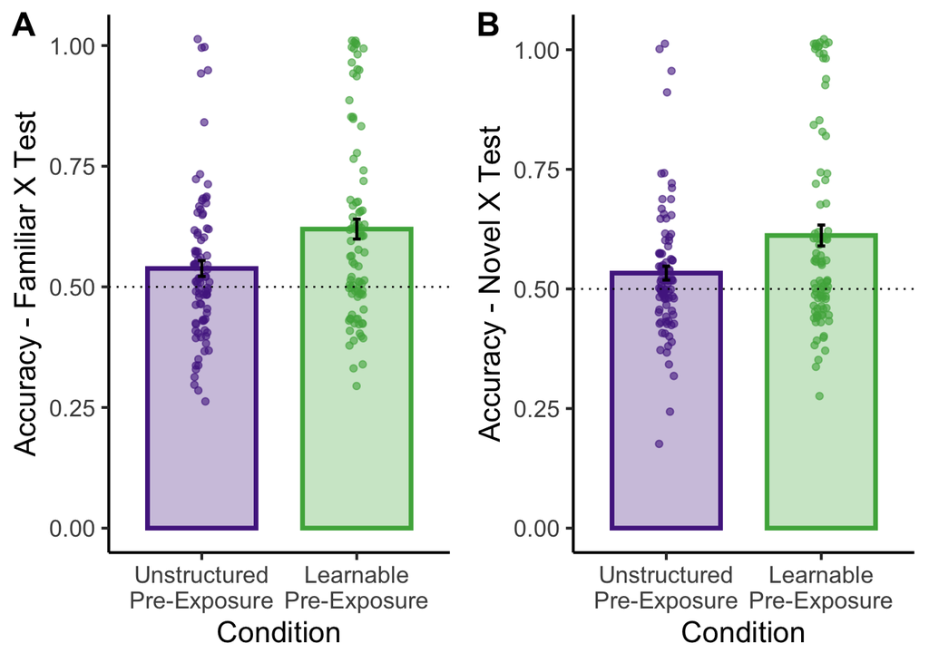

```r
#Familiar X test
p1 <- ggplot(subset(test_type_exp,testType=="familiarX"&exp=="exp3"),aes(condition,accuracy,fill=condition, color=condition))+
  geom_bar(position=position_dodge(.9), stat="identity", size=1.2,alpha=0.3, width=0.7)+
  geom_jitter(data=subset(subj_testType,testType=="familiarX"&exp=="exp3"),aes(y=acc), width = 0.05, alpha=0.6,shape=21)+
  geom_errorbar(aes(ymin=accuracy-se,ymax=accuracy+se),color="black",position=position_dodge(.9),width=0.05, size=0.8)+
  theme_classic(base_size=16)+
  geom_hline(yintercept=0.5, linetype="dotted")+
  scale_x_discrete(name="Condition",
                   breaks=c("Unstructured Pre-Exposure","Learnable Pre-Exposure"),
                   labels=c("Unstructured\nPre-Exposure","Learnable\nPre-Exposure"),
                   limits=c("Unstructured Pre-Exposure","Learnable Pre-Exposure"))+
  scale_fill_manual(values=c("#4DAF4A","#54278f"))+
  scale_color_manual(values=c("#4DAF4A","#54278f"))+
  theme(legend.position="none")+
  ylab("Accuracy - Familiar X Test")+
  xlab("Condition")

#Novel X
p2 <- ggplot(subset(test_type_exp,testType=="novelX"&exp=="exp3"),aes(condition,accuracy,fill=condition,color=condition))+
  geom_bar(position=position_dodge(.9), stat="identity", size=1.2,alpha=0.3, width=0.7)+
  geom_jitter(data=subset(subj_testType,testType=="novelX"&exp=="exp3"),aes(y=acc), width = 0.05, alpha=0.6,shape=21)+
  geom_errorbar(aes(ymin=accuracy-se,ymax=accuracy+se),color="black",position=position_dodge(.9),width=0.05, size=0.8)+
  theme_classic(base_size=16)+
  geom_hline(yintercept=0.5, linetype="dotted")+
  scale_x_discrete(name="Condition",
                   breaks=c("Unstructured Pre-Exposure","Learnable Pre-Exposure"),
                   labels=c("Unstructured\nPre-Exposure","Learnable\nPre-Exposure"),
                   limits=c("Unstructured Pre-Exposure","Learnable Pre-Exposure"))+
  scale_fill_manual(values=c("#4DAF4A","#54278f"))+
  scale_color_manual(values=c("#4DAF4A","#54278f"))+
  theme(legend.position="none")+
  ylab("Accuracy - Novel X Test")+
  xlab("Condition")
plot_grid(p1,p2, labels=c("A","B"),label_size=18)
```

#### Overall Accuracy Table

```r
overall_exp %>%
  filter(exp=="exp3") %>%
  select(-c(se, accuracy_ci,d_prime_ci,c_bias_ci)) %>%
  formattable()
```

| exp | condition | N | accuracy | accuracy_lower_ci | accuracy_upper_ci | d_prime | d_prime_lower_ci | d_prime_upper_ci | c_bias | c_bias_lower_ci | c_bias_upper_ci |
| --- | --- | --- | --- | --- | --- | --- | --- | --- | --- | --- | --- |
| exp3 | Learnable Pre-Exposure | 90 | 0.6157407 | 0.5761732 | 0.6553082 | 0.7932834 | 0.5051798 | 1.0813870 | -0.1471900 | -0.2255496 | -0.06883044 |
| exp3 | Unstructured Pre-Exposure | 89 | 0.5355805 | 0.5085204 | 0.5626406 | 0.2401722 | 0.0604255 | 0.4199189 | -0.1638137 | -0.2497717 | -0.07785573 |

#### Accuracy Table By Test Type

```r
test_type_exp %>%
  filter(exp=="exp3") %>%
  select(-c(se, accuracy_ci,d_prime_ci,c_bias_ci)) %>%
  formattable()
```

| exp | condition | testType | N | accuracy | accuracy_lower_ci | accuracy_upper_ci | d_prime | d_prime_lower_ci | d_prime_upper_ci | c_bias | c_bias_lower_ci | c_bias_upper_ci |
| --- | --- | --- | --- | --- | --- | --- | --- | --- | --- | --- | --- | --- |
| exp3 | Learnable Pre-Exposure | familiarX | 90 | 0.6197531 | 0.5787377 | 0.6607685 | 0.7360229 | 0.48172951 | 0.9903163 | -0.3575601 | -0.45300126 | -0.2621189 |
| exp3 | Learnable Pre-Exposure | novelX | 90 | 0.6117284 | 0.5682435 | 0.6552133 | 0.6917028 | 0.41857251 | 0.9648331 | 0.0653921 | -0.04610090 | 0.1768851 |
| exp3 | Unstructured Pre-Exposure | familiarX | 89 | 0.5380774 | 0.5053266 | 0.5708282 | 0.2373254 | 0.03843109 | 0.4362197 | -0.4554699 | -0.55536408 | -0.3555757 |
| exp3 | Unstructured Pre-Exposure | novelX | 89 | 0.5330836 | 0.5043785 | 0.5617888 | 0.2000827 | 0.02878172 | 0.3713837 | 0.1334533 | -0.01092315 | 0.2778297 |

#### Correlation

##### Correlation between Familiar X and Novel X Trials

##### Learnable Pre-Exposure

```r
##Correlations between Familiar X and Novel X
c <- corr.test(subset(subj_accuracy_wide, condition=="Learnable Pre-Exposure" & exp=="exp3")[,c("novelX","familiarX")])
c
```

```
## Call:corr.test(x = subset(subj_accuracy_wide, condition == "Learnable Pre-Exposure" &
##     exp == "exp3")[, c("novelX", "familiarX")])
## Correlation matrix
##           novelX familiarX
## novelX      1.00      0.75
## familiarX   0.75      1.00
## Sample Size
## [1] 90
## Probability values (Entries above the diagonal are adjusted for multiple tests.)
##           novelX familiarX
## novelX         0         0
## familiarX      0         0
##
##  To see confidence intervals of the correlations, print with the short=FALSE option
```

```r
c$p
```

```
##                 novelX    familiarX
## novelX    0.000000e+00 9.870517e-18
## familiarX 9.870517e-18 0.000000e+00
```

##### Unstructured Pre-Exposure

```r
c <- corr.test(subset(subj_accuracy_wide, condition=="Unstructured Pre-Exposure" & exp=="exp3")[,c("novelX","familiarX")])
c
```

```
## Call:corr.test(x = subset(subj_accuracy_wide, condition == "Unstructured Pre-Exposure" &
##     exp == "exp3")[, c("novelX", "familiarX")])
## Correlation matrix
##           novelX familiarX
## novelX      1.00      0.55
## familiarX   0.55      1.00
## Sample Size
## [1] 89
## Probability values (Entries above the diagonal are adjusted for multiple tests.)
##           novelX familiarX
## novelX         0         0
## familiarX      0         0
##
##  To see confidence intervals of the correlations, print with the short=FALSE option
```

```r
c$p
```

```
##                 novelX    familiarX
## novelX    0.000000e+00 2.524806e-08
## familiarX 2.524806e-08 0.000000e+00
```

##### Interaction between Test Type and Condition

```r
m <- lm(novelX~familiarX*condition, subset(subj_accuracy_wide,exp=="exp3"))
summary(m)
```

```
##
## Call:
## lm(formula = novelX ~ familiarX * condition, data = subset(subj_accuracy_wide,
##     exp == "exp3"))
##
## Residuals:
##      Min       1Q   Median       3Q      Max
## -0.33799 -0.08303  0.01198  0.07857  0.36172
##
## Coefficients:
##                                              Estimate Std. Error t value
## (Intercept)                                   0.11638    0.04446   2.618
## familiarX                                     0.79926    0.06844  11.679
## conditionUnstructured Pre-Exposure            0.15775    0.06582   2.397
## familiarX:conditionUnstructured Pre-Exposure -0.31801    0.11045  -2.879
##                                              Pr(>|t|)
## (Intercept)                                   0.00963 **
## familiarX                                     < 2e-16 ***
## conditionUnstructured Pre-Exposure            0.01759 *
## familiarX:conditionUnstructured Pre-Exposure  0.00448 **
## ---
## Signif. codes:  0 '***' 0.001 '**' 0.01 '*' 0.05 '.' 0.1 ' ' 1
##
## Residual standard error: 0.1264 on 175 degrees of freedom
## Multiple R-squared:  0.5132, Adjusted R-squared:  0.5049
## F-statistic: 61.51 on 3 and 175 DF,  p-value: < 2.2e-16
```

#### Correlation Plot

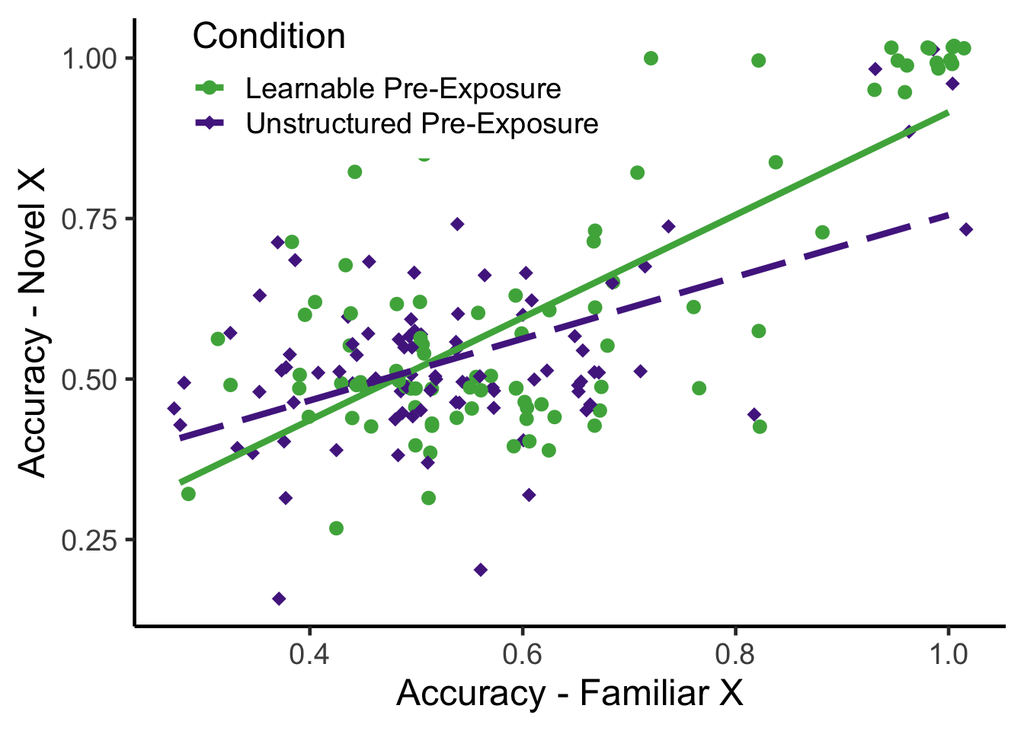

```r
ggplot(subset(subj_accuracy_wide,exp=="exp3"),aes(familiarX,novelX, color=condition,linetype=condition,shape=condition))+
  geom_jitter(width=0.02,height=0.02,size=3)+
  geom_smooth(method=lm,se =F,size=1.5)+
  scale_color_manual(name="Condition",values=c("#4DAF4A","#54278f"))+
  scale_linetype_manual(name="Condition",values=c(1,5))+
  scale_shape_manual(name="Condition",values=c(16,18))+
  ylab("Accuracy - Novel X")+
  xlab("Accuracy - Familiar X")+
  theme_classic(base_size=18)+
  theme(legend.position=c(0.3,0.9))
```

### Logistic Mixed-Effects Model

#### Overall

##### Final Converging Model

The final model with the maximal random effects structure that still allowed the model to converge.

```r
#recode condition
d$conditionC <- ifelse(d$condition=="Learnable Pre-Exposure",0.5,
                    ifelse(d$condition=="Unstructured Pre-Exposure",-0.5,NA))
##all data
m <- glmer(isRight~conditionC+(1|participantCode)+(1|stimulus),data=subset(d,exp=="exp3"),family=binomial,glmerControl(optimizer="bobyqa"))
summary(m)
```

```
## Generalized linear mixed model fit by maximum likelihood (Laplace
##   Approximation) [glmerMod]
##  Family: binomial  ( logit )
## Formula: isRight ~ conditionC + (1 | participantCode) + (1 | stimulus)
##    Data: subset(d, exp == "exp3")
## Control: glmerControl(optimizer = "bobyqa")
##
##      AIC      BIC   logLik deviance df.resid
##   8420.2   8447.2  -4206.1   8412.2     6440
##
## Scaled residuals:
##     Min      1Q  Median      3Q     Max
## -3.0204 -1.0153  0.3568  0.9141  1.4900
##
## Random effects:
##  Groups          Name        Variance Std.Dev.
##  participantCode (Intercept) 0.600740 0.77507
##  stimulus        (Intercept) 0.004486 0.06697
## Number of obs: 6444, groups:  participantCode, 179; stimulus, 36
##
## Fixed effects:
##             Estimate Std. Error z value Pr(>|z|)
## (Intercept)   0.3848     0.0655   5.876 4.21e-09 ***
## conditionC    0.4254     0.1285   3.309 0.000935 ***
## ---
## Signif. codes:  0 '***' 0.001 '**' 0.01 '*' 0.05 '.' 0.1 ' ' 1
##
## Correlation of Fixed Effects:
##            (Intr)
## conditionC 0.019
```

```r
confint(m, method="Wald")
```

```
##                 2.5 %    97.5 %
## .sig01             NA        NA
## .sig02             NA        NA
## (Intercept) 0.2564603 0.5131961
## conditionC  0.1734409 0.6772993
```

##### Maximal Random Effects Model

Note that this model does not converge (singular fit), thus the parameter estimates should be interpreted with caution.

```r
#maximal model
m <- glmer(isRight~conditionC+(1|participantCode)+(1+conditionC|stimulus),data=subset(d,exp=="exp3"),family=binomial,glmerControl(optimizer="bobyqa"))
```

```
## boundary (singular) fit: see ?isSingular
```

```r
summary(m)
```

```
## Generalized linear mixed model fit by maximum likelihood (Laplace
##   Approximation) [glmerMod]
##  Family: binomial  ( logit )
## Formula: isRight ~ conditionC + (1 | participantCode) + (1 + conditionC |
##     stimulus)
##    Data: subset(d, exp == "exp3")
## Control: glmerControl(optimizer = "bobyqa")
##
##      AIC      BIC   logLik deviance df.resid
##   8423.4   8464.0  -4205.7   8411.4     6438
##
## Scaled residuals:
##     Min      1Q  Median      3Q     Max
## -3.0103 -1.0155  0.3546  0.9121  1.5246
##
## Random effects:
##  Groups          Name        Variance Std.Dev. Corr
##  participantCode (Intercept) 0.601095 0.77530
##  stimulus        (Intercept) 0.006028 0.07764
##                  conditionC  0.005060 0.07113  -1.00
## Number of obs: 6444, groups:  participantCode, 179; stimulus, 36
##
## Fixed effects:
##             Estimate Std. Error z value Pr(>|z|)
## (Intercept)  0.38485    0.06584   5.845 5.06e-09 ***
## conditionC   0.42487    0.12913   3.290    0.001 **
## ---
## Signif. codes:  0 '***' 0.001 '**' 0.01 '*' 0.05 '.' 0.1 ' ' 1
##
## Correlation of Fixed Effects:
##            (Intr)
## conditionC 0.001
## convergence code: 0
## boundary (singular) fit: see ?isSingular
```

```r
confint(m, method="Wald")[5:6,]
```

```
##                 2.5 %    97.5 %
## (Intercept) 0.2558063 0.5138941
## conditionC  0.1717902 0.6779561
```

#### Familiar X Trials

##### Condition Effect

###### Final Converging Model

The final model with the maximal random effects structure that still allowed the model to converge, as reported in the manuscript.

```r
m <- glmer(isRight~conditionC+(1|participantCode),data=subset(d,exp=="exp3"&testType=="familiarX"),family=binomial,glmerControl(optimizer="bobyqa"))
summary(m)
```

```
## Generalized linear mixed model fit by maximum likelihood (Laplace
##   Approximation) [glmerMod]
##  Family: binomial  ( logit )
## Formula: isRight ~ conditionC + (1 | participantCode)
##    Data: subset(d, exp == "exp3" & testType == "familiarX")
## Control: glmerControl(optimizer = "bobyqa")
##
##      AIC      BIC   logLik deviance df.resid
##   4271.3   4289.5  -2132.7   4265.3     3219
##
## Scaled residuals:
##     Min      1Q  Median      3Q     Max
## -2.1365 -1.0299  0.4681  0.9022  1.3070
##
## Random effects:
##  Groups          Name        Variance Std.Dev.
##  participantCode (Intercept) 0.4302   0.6559
## Number of obs: 3222, groups:  participantCode, 179
##
## Fixed effects:
##             Estimate Std. Error z value Pr(>|z|)
## (Intercept)  0.36486    0.06222   5.864 4.52e-09 ***
## conditionC   0.38408    0.12387   3.101  0.00193 **
## ---
## Signif. codes:  0 '***' 0.001 '**' 0.01 '*' 0.05 '.' 0.1 ' ' 1
##
## Correlation of Fixed Effects:
##            (Intr)
## conditionC 0.018
```

```r
confint(m, method="Wald")
```

```
##                 2.5 %    97.5 %
## .sig01             NA        NA
## (Intercept) 0.2429110 0.4868076
## conditionC  0.1412912 0.6268640
```

###### Maximal Random Effects Model

Note that this model does not converge (singular fit), thus the parameter estimates should be interpreted with caution (though the parameter estimates and test statistics are highly similar to the converging model).

```r
#maximal model
m <- glmer(isRight~conditionC+(1|participantCode)+(1+conditionC|stimulus),data=subset(d,exp=="exp3"&testType=="familiarX"),family=binomial,glmerControl(optimizer="bobyqa")) #convergence warning
```

```
## boundary (singular) fit: see ?isSingular
```

```r
summary(m)
```

```
## Generalized linear mixed model fit by maximum likelihood (Laplace
##   Approximation) [glmerMod]
##  Family: binomial  ( logit )
## Formula: isRight ~ conditionC + (1 | participantCode) + (1 + conditionC |
##     stimulus)
##    Data: subset(d, exp == "exp3" & testType == "familiarX")
## Control: glmerControl(optimizer = "bobyqa")
##
##      AIC      BIC   logLik deviance df.resid
##   4277.3   4313.8  -2132.7   4265.3     3216
##
## Scaled residuals:
##     Min      1Q  Median      3Q     Max
## -2.1365 -1.0299  0.4681  0.9022  1.3070
##
## Random effects:
##  Groups          Name        Variance  Std.Dev.  Corr
##  participantCode (Intercept) 4.302e-01 6.559e-01
##  stimulus        (Intercept) 2.777e-12 1.666e-06
##                  conditionC  8.156e-12 2.856e-06 -1.00
## Number of obs: 3222, groups:  participantCode, 179; stimulus, 18
##
## Fixed effects:
##             Estimate Std. Error z value Pr(>|z|)
## (Intercept)  0.36486    0.06222   5.864 4.52e-09 ***
## conditionC   0.38408    0.12387   3.101  0.00193 **
## ---
## Signif. codes:  0 '***' 0.001 '**' 0.01 '*' 0.05 '.' 0.1 ' ' 1
##
## Correlation of Fixed Effects:
##            (Intr)
## conditionC 0.018
## convergence code: 0
## boundary (singular) fit: see ?isSingular
```

```r
confint(m, method="Wald")[5:6,]
```

```
##                 2.5 %    97.5 %
## (Intercept) 0.2429104 0.4868084
## conditionC  0.1412901 0.6268634
```

##### Testing against chance: Learnable Pre-Exposure

###### Final Converging Model

The final model with the maximal random effects structure that still allowed the model to converge, as reported in the manuscript.

```r
m <- glmer(isRight~1+(1|participantCode),data=subset(d,exp=="exp3"&testType=="familiarX"&conditionC==0.5),family=binomial,glmerControl(optimizer="bobyqa"))
summary(m)
```

```
## Generalized linear mixed model fit by maximum likelihood (Laplace
##   Approximation) [glmerMod]
##  Family: binomial  ( logit )
## Formula: isRight ~ 1 + (1 | participantCode)
##    Data:
## subset(d, exp == "exp3" & testType == "familiarX" & conditionC ==
##     0.5)
## Control: glmerControl(optimizer = "bobyqa")
##
##      AIC      BIC   logLik deviance df.resid
##   2064.3   2075.1  -1030.2   2060.3     1618
##
## Scaled residuals:
##     Min      1Q  Median      3Q     Max
## -2.4478 -0.9814  0.4085  0.7845  1.3262
##
## Random effects:
##  Groups          Name        Variance Std.Dev.
##  participantCode (Intercept) 0.76     0.8718
## Number of obs: 1620, groups:  participantCode, 90
##
## Fixed effects:
##             Estimate Std. Error z value Pr(>|z|)
## (Intercept)   0.5939     0.1090    5.45 5.04e-08 ***
## ---
## Signif. codes:  0 '***' 0.001 '**' 0.01 '*' 0.05 '.' 0.1 ' ' 1
```

```r
confint(m, method="Wald")
```

```
##                 2.5 %    97.5 %
## .sig01             NA        NA
## (Intercept) 0.3803136 0.8074874
```

###### Maximal Random Effects Model

Note that this model does not converge (singular fit), thus the parameter estimates should be interpreted with caution (though the parameter estimates and test statistics are highly similar to the converging model).

```r
m <- glmer(isRight~1+(1|participantCode)+(1|stimulus),data=subset(d,exp=="exp3"&testType=="familiarX"&conditionC==0.5),family=binomial,glmerControl(optimizer="bobyqa"))
```

```
## boundary (singular) fit: see ?isSingular
```

```r
summary(m)
```

```
## Generalized linear mixed model fit by maximum likelihood (Laplace
##   Approximation) [glmerMod]
##  Family: binomial  ( logit )
## Formula: isRight ~ 1 + (1 | participantCode) + (1 | stimulus)
##    Data:
## subset(d, exp == "exp3" & testType == "familiarX" & conditionC ==
##     0.5)
## Control: glmerControl(optimizer = "bobyqa")
##
##      AIC      BIC   logLik deviance df.resid
##   2066.3   2082.5  -1030.2   2060.3     1617
##
## Scaled residuals:
##     Min      1Q  Median      3Q     Max
## -2.4478 -0.9814  0.4085  0.7845  1.3262
##
## Random effects:
##  Groups          Name        Variance Std.Dev.
##  participantCode (Intercept) 0.76     0.8718
##  stimulus        (Intercept) 0.00     0.0000
## Number of obs: 1620, groups:  participantCode, 90; stimulus, 18
##
## Fixed effects:
##             Estimate Std. Error z value Pr(>|z|)
## (Intercept)   0.5939     0.1090    5.45 5.04e-08 ***
## ---
## Signif. codes:  0 '***' 0.001 '**' 0.01 '*' 0.05 '.' 0.1 ' ' 1
## convergence code: 0
## boundary (singular) fit: see ?isSingular
```

```r
confint(m, method="Wald")
```

```
##                 2.5 %    97.5 %
## .sig01             NA        NA
## .sig02             NA        NA
## (Intercept) 0.3803169 0.8074857
```

##### Testing against chance: Unstructured Pre-Exposure

###### Final Converging Model

The final model with the maximal random effects structure that still allowed the model to converge, as reported in the manuscript.

```r
m <- glmer(isRight~1+(1|participantCode),data=subset(d,exp=="exp3"&testType=="familiarX"&conditionC==-0.5),family=binomial,glmerControl(optimizer="bobyqa"))
summary(m)
```

```
## Generalized linear mixed model fit by maximum likelihood (Laplace
##   Approximation) [glmerMod]
##  Family: binomial  ( logit )
## Formula: isRight ~ 1 + (1 | participantCode)
##    Data:
## subset(d, exp == "exp3" & testType == "familiarX" & conditionC ==
##     -0.5)
## Control: glmerControl(optimizer = "bobyqa")
##
##      AIC      BIC   logLik deviance df.resid
##   2197.9   2208.7  -1097.0   2193.9     1600
##
## Scaled residuals:
##     Min      1Q  Median      3Q     Max
## -1.6037 -1.0443  0.6236  0.9092  1.1787
##
## Random effects:
##  Groups          Name        Variance Std.Dev.
##  participantCode (Intercept) 0.1937   0.4401
## Number of obs: 1602, groups:  participantCode, 89
##
## Fixed effects:
##             Estimate Std. Error z value Pr(>|z|)
## (Intercept)  0.16208    0.06942   2.335   0.0195 *
## ---
## Signif. codes:  0 '***' 0.001 '**' 0.01 '*' 0.05 '.' 0.1 ' ' 1
```

```r
confint(m, method="Wald")
```

```
##                  2.5 %    97.5 %
## .sig01              NA        NA
## (Intercept) 0.02602679 0.2981361
```

###### Maximal Random Effects Model

Note that this model does not converge (singular fit), thus the parameter estimates should be interpreted with caution (though the parameter estimates and test statistics are highly similar to the converging model).

```r
m <- glmer(isRight~1+(1|participantCode)+(1|stimulus),data=subset(d,exp=="exp3"&testType=="familiarX"&conditionC==-0.5),family=binomial,glmerControl(optimizer="bobyqa"))
```

```
## boundary (singular) fit: see ?isSingular
```

```r
summary(m)
```

```
## Generalized linear mixed model fit by maximum likelihood (Laplace
##   Approximation) [glmerMod]
##  Family: binomial  ( logit )
## Formula: isRight ~ 1 + (1 | participantCode) + (1 | stimulus)
##    Data:
## subset(d, exp == "exp3" & testType == "familiarX" & conditionC ==
##     -0.5)
## Control: glmerControl(optimizer = "bobyqa")
##
##      AIC      BIC   logLik deviance df.resid
##   2199.9   2216.1  -1097.0   2193.9     1599
##
## Scaled residuals:
##     Min      1Q  Median      3Q     Max
## -1.6037 -1.0443  0.6236  0.9092  1.1787
##
## Random effects:
##  Groups          Name        Variance Std.Dev.
##  participantCode (Intercept) 0.1937   0.4401
##  stimulus        (Intercept) 0.0000   0.0000
## Number of obs: 1602, groups:  participantCode, 89; stimulus, 18
##
## Fixed effects:
##             Estimate Std. Error z value Pr(>|z|)
## (Intercept)  0.16208    0.06942   2.335   0.0195 *
## ---
## Signif. codes:  0 '***' 0.001 '**' 0.01 '*' 0.05 '.' 0.1 ' ' 1
## convergence code: 0
## boundary (singular) fit: see ?isSingular
```

```r
confint(m, method="Wald")
```

```
##                  2.5 %    97.5 %
## .sig01              NA        NA
## .sig02              NA        NA
## (Intercept) 0.02602678 0.2981357
```

#### Novel X Trials

##### Condition Effect

###### Final Converging Model

The final model with the maximal random effects structure that still allowed the model to converge, as reported in the manuscript.

```r
m <- glmer(isRight~conditionC+(1|participantCode)+(1|stimulus),data=subset(d,exp=="exp3"&testType=="novelX"),family=binomial,glmerControl(optimizer="bobyqa"))
summary(m)
```

```
## Generalized linear mixed model fit by maximum likelihood (Laplace
##   Approximation) [glmerMod]
##  Family: binomial  ( logit )
## Formula: isRight ~ conditionC + (1 | participantCode) + (1 | stimulus)
##    Data: subset(d, exp == "exp3" & testType == "novelX")
## Control: glmerControl(optimizer = "bobyqa")
##
##      AIC      BIC   logLik deviance df.resid
##   4288.8   4313.1  -2140.4   4280.8     3218
##
## Scaled residuals:
##     Min      1Q  Median      3Q     Max
## -2.1169 -1.0178  0.4405  0.9043  1.6234
##
## Random effects:
##  Groups          Name        Variance Std.Dev.
##  participantCode (Intercept) 0.4370   0.6610
##  stimulus        (Intercept) 0.0136   0.1166
## Number of obs: 3222, groups:  participantCode, 179; stimulus, 18
##
## Fixed effects:
##             Estimate Std. Error z value Pr(>|z|)
## (Intercept)  0.33919    0.06834   4.963 6.93e-07 ***
## conditionC   0.38311    0.12467   3.073  0.00212 **
## ---
## Signif. codes:  0 '***' 0.001 '**' 0.01 '*' 0.05 '.' 0.1 ' ' 1
##
## Correlation of Fixed Effects:
##            (Intr)
## conditionC 0.022
```

```r
confint(m, method="Wald")
```

```
##                 2.5 %    97.5 %
## .sig01             NA        NA
## .sig02             NA        NA
## (Intercept) 0.2052465 0.4731307
## conditionC  0.1387632 0.6274558
```

###### Maximal Random Effects Model

Note that this model does not converge (singular fit), thus the parameter estimates should be interpreted with caution (though the parameter estimates and test statistics are highly similar to the converging model).

```r
m <- glmer(isRight~conditionC+(1|participantCode)+(1+conditionC|stimulus),data=subset(d,exp=="exp3"&testType=="novelX"),family=binomial,glmerControl(optimizer="bobyqa"))
```

```
## boundary (singular) fit: see ?isSingular
```

```r
summary(m)
```

```
## Generalized linear mixed model fit by maximum likelihood (Laplace
##   Approximation) [glmerMod]
##  Family: binomial  ( logit )
## Formula: isRight ~ conditionC + (1 | participantCode) + (1 + conditionC |
##     stimulus)
##    Data: subset(d, exp == "exp3" & testType == "novelX")
## Control: glmerControl(optimizer = "bobyqa")
##
##      AIC      BIC   logLik deviance df.resid
##   4292.1   4328.5  -2140.0   4280.1     3216
##
## Scaled residuals:
##     Min      1Q  Median      3Q     Max
## -2.1229 -1.0235  0.4378  0.9032  1.6613
##
## Random effects:
##  Groups          Name        Variance Std.Dev. Corr
##  participantCode (Intercept) 0.43693  0.66101
##  stimulus        (Intercept) 0.01427  0.11945
##                  conditionC  0.00701  0.08373  -1.00
## Number of obs: 3222, groups:  participantCode, 179; stimulus, 18
##
## Fixed effects:
##             Estimate Std. Error z value Pr(>|z|)
## (Intercept)  0.33901    0.06862   4.941 7.78e-07 ***
## conditionC   0.38201    0.12623   3.026  0.00248 **
## ---
## Signif. codes:  0 '***' 0.001 '**' 0.01 '*' 0.05 '.' 0.1 ' ' 1
##
## Correlation of Fixed Effects:
##            (Intr)
## conditionC -0.043
## convergence code: 0
## boundary (singular) fit: see ?isSingular
```

```r
confint(m, method="Wald")[5:6,]
```

```
##                 2.5 %    97.5 %
## (Intercept) 0.2045242 0.4734924
## conditionC  0.1345932 0.6294225
```

##### Testing against chance: Learnable Pre-Exposure

###### Final Converging Model

The final model with the maximal random effects structure that still allowed the model to converge, as reported in the manuscript.

```r
m <- glmer(isRight~1+(1|participantCode),data=subset(d,exp=="exp3"&testType=="novelX"&conditionC==0.5),family=binomial,glmerControl(optimizer="bobyqa"))
summary(m)
```

```
## Generalized linear mixed model fit by maximum likelihood (Laplace
##   Approximation) [glmerMod]
##  Family: binomial  ( logit )
## Formula: isRight ~ 1 + (1 | participantCode)
##    Data: subset(d, exp == "exp3" & testType == "novelX" & conditionC ==
##     0.5)
## Control: glmerControl(optimizer = "bobyqa")
##
##      AIC      BIC   logLik deviance df.resid
##   2046.6   2057.4  -1021.3   2042.6     1618
##
## Scaled residuals:
##     Min      1Q  Median      3Q     Max
## -2.6331 -0.9616  0.3150  0.8649  1.3816
##
## Random effects:
##  Groups          Name        Variance Std.Dev.
##  participantCode (Intercept) 1.051    1.025
## Number of obs: 1620, groups:  participantCode, 90
##
## Fixed effects:
##             Estimate Std. Error z value Pr(>|z|)
## (Intercept)   0.6025     0.1246   4.834 1.34e-06 ***
## ---
## Signif. codes:  0 '***' 0.001 '**' 0.01 '*' 0.05 '.' 0.1 ' ' 1
```

```r
confint(m, method="Wald")
```

```
##                 2.5 %   97.5 %
## .sig01             NA       NA
## (Intercept) 0.3582096 0.846745
```

###### Maximal Random Effects Model

Note that this model does not converge (singular fit), thus the parameter estimates should be interpreted with caution (though the parameter estimates and test statistics are highly similar to the converging model).

```r
m <- glmer(isRight~1+(1|participantCode)+(1|stimulus),data=subset(d,exp=="exp3"&testType=="novelX"&conditionC==0.5),family=binomial,glmerControl(optimizer="bobyqa"))
```

```
## boundary (singular) fit: see ?isSingular
```

```r
summary(m)
```

```
## Generalized linear mixed model fit by maximum likelihood (Laplace
##   Approximation) [glmerMod]
##  Family: binomial  ( logit )
## Formula: isRight ~ 1 + (1 | participantCode) + (1 | stimulus)
##    Data: subset(d, exp == "exp3" & testType == "novelX" & conditionC ==
##     0.5)
## Control: glmerControl(optimizer = "bobyqa")
##
##      AIC      BIC   logLik deviance df.resid
##   2048.6   2064.8  -1021.3   2042.6     1617
##
## Scaled residuals:
##     Min      1Q  Median      3Q     Max
## -2.6332 -0.9616  0.3150  0.8649  1.3816
##
## Random effects:
##  Groups          Name        Variance Std.Dev.
##  participantCode (Intercept) 1.051    1.025
##  stimulus        (Intercept) 0.000    0.000
## Number of obs: 1620, groups:  participantCode, 90; stimulus, 18
##
## Fixed effects:
##             Estimate Std. Error z value Pr(>|z|)
## (Intercept)   0.6025     0.1246   4.834 1.34e-06 ***
## ---
## Signif. codes:  0 '***' 0.001 '**' 0.01 '*' 0.05 '.' 0.1 ' ' 1
## convergence code: 0
## boundary (singular) fit: see ?isSingular
```

```r
confint(m, method="Wald")
```

```
##                 2.5 %    97.5 %
## .sig01             NA        NA
## .sig02             NA        NA
## (Intercept) 0.3582252 0.8468066
```

##### Testing against chance: Unstructured Pre-Exposure

###### Final Converging Model

The final model with the maximal random effects structure that still allowed the model to converge, as reported in the manuscript.

```r
m <- glmer(isRight~1+(1|participantCode)+(1|stimulus),data=subset(d,exp=="exp3"&testType=="novelX"&conditionC==-0.5),family=binomial,glmerControl(optimizer="bobyqa"))
summary(m)
```

```
## Generalized linear mixed model fit by maximum likelihood (Laplace
##   Approximation) [glmerMod]
##  Family: binomial  ( logit )
## Formula: isRight ~ 1 + (1 | participantCode) + (1 | stimulus)
##    Data: subset(d, exp == "exp3" & testType == "novelX" & conditionC ==
##     -0.5)
## Control: glmerControl(optimizer = "bobyqa")
##
##      AIC      BIC   logLik deviance df.resid
##   2214.6   2230.8  -1104.3   2208.6     1599
##
## Scaled residuals:
##     Min      1Q  Median      3Q     Max
## -1.3338 -1.0401  0.7710  0.9299  1.1929
##
## Random effects:
##  Groups          Name        Variance Std.Dev.
##  participantCode (Intercept) 0.08077  0.2842
##  stimulus        (Intercept) 0.01810  0.1346
## Number of obs: 1602, groups:  participantCode, 89; stimulus, 18
##
## Fixed effects:
##             Estimate Std. Error z value Pr(>|z|)
## (Intercept)  0.13604    0.06698   2.031   0.0422 *
## ---
## Signif. codes:  0 '***' 0.001 '**' 0.01 '*' 0.05 '.' 0.1 ' ' 1
```

```r
confint(m, method="Wald")
```

```
##                   2.5 %    97.5 %
## .sig01               NA        NA
## .sig02               NA        NA
## (Intercept) 0.004761652 0.2673123
```

#### Interaction between test type and condition

##### Final Converging Model

The final model with the maximal random effects structure that still allowed the model to converge.

```r
#recode test type
d$testTypeC <- ifelse(d$testType=="novelX",0.5,
                    ifelse(d$testType=="familiarX",-0.5,NA))
##all data
m <- glmer(isRight~conditionC*testTypeC+(1|participantCode)+(1|stimulus),data=subset(d,exp=="exp3"),family=binomial,glmerControl(optimizer="bobyqa"))
summary(m)
```

```
## Generalized linear mixed model fit by maximum likelihood (Laplace
##   Approximation) [glmerMod]
##  Family: binomial  ( logit )
## Formula: isRight ~ conditionC * testTypeC + (1 | participantCode) + (1 |
##     stimulus)
##    Data: subset(d, exp == "exp3")
## Control: glmerControl(optimizer = "bobyqa")
##
##      AIC      BIC   logLik deviance df.resid
##   8423.9   8464.5  -4205.9   8411.9     6438
##
## Scaled residuals:
##     Min      1Q  Median      3Q     Max
## -3.0446 -1.0163  0.3558  0.9145  1.4950
##
## Random effects:
##  Groups          Name        Variance Std.Dev.
##  participantCode (Intercept) 0.60076  0.77509
##  stimulus        (Intercept) 0.00426  0.06527
## Number of obs: 6444, groups:  participantCode, 179; stimulus, 36
##
## Fixed effects:
##                      Estimate Std. Error z value Pr(>|z|)
## (Intercept)           0.38483    0.06545   5.880 4.11e-09 ***
## conditionC            0.42539    0.12854   3.309 0.000935 ***
## testTypeC            -0.02990    0.05730  -0.522 0.601772
## conditionC:testTypeC -0.01681    0.10602  -0.159 0.874005
## ---
## Signif. codes:  0 '***' 0.001 '**' 0.01 '*' 0.05 '.' 0.1 ' ' 1
##
## Correlation of Fixed Effects:
##             (Intr) cndtnC tstTyC
## conditionC   0.019
## testTypeC   -0.001 -0.001
## cndtnC:tsTC -0.001 -0.001  0.041
```

```r
confint(m, method="Wald")[3:6,]
```

```
##                           2.5 %     97.5 %
## (Intercept)           0.2565559 0.51311242
## conditionC            0.1734545 0.67732689
## testTypeC            -0.1422117 0.08240574
## conditionC:testTypeC -0.2246079 0.19098383
```

##### Maximal Random Effects Model

Note that this model does not converge (singular fit), thus the parameter estimates should be interpreted with caution.

```r
##all data
m <- glmer(isRight~conditionC*testTypeC+(1+testTypeC|participantCode)+(1+conditionC|stimulus),data=subset(d,exp=="exp3"),family=binomial,glmerControl(optimizer="bobyqa"))
```

```
## boundary (singular) fit: see ?isSingular
```

```r
summary(m)
```

```
## Generalized linear mixed model fit by maximum likelihood (Laplace
##   Approximation) [glmerMod]
##  Family: binomial  ( logit )
## Formula:
## isRight ~ conditionC * testTypeC + (1 + testTypeC | participantCode) +
##     (1 + conditionC | stimulus)
##    Data: subset(d, exp == "exp3")
## Control: glmerControl(optimizer = "bobyqa")
##
##      AIC      BIC   logLik deviance df.resid
##   8431.0   8498.8  -4205.5   8411.0     6434
##
## Scaled residuals:
##     Min      1Q  Median      3Q     Max
## -3.0524 -1.0177  0.3537  0.9142  1.5229
##
## Random effects:
##  Groups          Name        Variance  Std.Dev. Corr
##  participantCode (Intercept) 6.011e-01 0.775307
##                  testTypeC   9.903e-05 0.009951 -1.00
##  stimulus        (Intercept) 5.873e-03 0.076637
##                  conditionC  5.111e-03 0.071495 -1.00
## Number of obs: 6444, groups:  participantCode, 179; stimulus, 36
##
## Fixed effects:
##                      Estimate Std. Error z value Pr(>|z|)
## (Intercept)           0.38486    0.06581   5.848 4.97e-09 ***
## conditionC            0.42483    0.12913   3.290    0.001 **
## testTypeC            -0.03192    0.06093  -0.524    0.600
## conditionC:testTypeC -0.01920    0.11031  -0.174    0.862
## ---
## Signif. codes:  0 '***' 0.001 '**' 0.01 '*' 0.05 '.' 0.1 ' ' 1
##
## Correlation of Fixed Effects:
##             (Intr) cndtnC tstTyC
## conditionC   0.001
## testTypeC   -0.013  0.000
## cndtnC:tsTC -0.001 -0.013 -0.010
## convergence code: 0
## boundary (singular) fit: see ?isSingular
```

```r
confint(m, method="Wald")[7:10,]
```

```
##                           2.5 %     97.5 %
## (Intercept)           0.2558836 0.51384564
## conditionC            0.1717295 0.67792630
## testTypeC            -0.1513293 0.08749837
## conditionC:testTypeC -0.2354027 0.19701156
```

### Signal Detection Model

#### Sensitivity

##### Overall

```r
#recode condition
subj_overall$conditionC <- ifelse(subj_overall$condition=="Learnable Pre-Exposure",0.5,
                    ifelse(subj_overall$condition=="Unstructured Pre-Exposure",-0.5,NA))
##all data
m <- lm(dprime~conditionC,data=subset(subj_overall,exp=="exp3"))
summary(m)
```

```
##
## Call:
## lm(formula = dprime ~ conditionC, data = subset(subj_overall,
##     exp == "exp3"))
##
## Residuals:
##     Min      1Q  Median      3Q     Max
## -1.8135 -0.6835 -0.2402  0.1862  3.5888
##
## Coefficients:
##             Estimate Std. Error t value Pr(>|t|)
## (Intercept)  0.51673    0.08566   6.032 9.21e-09 ***
## conditionC   0.55311    0.17132   3.229  0.00148 **
## ---
## Signif. codes:  0 '***' 0.001 '**' 0.01 '*' 0.05 '.' 0.1 ' ' 1
##
## Residual standard error: 1.146 on 177 degrees of freedom
## Multiple R-squared:  0.05561,    Adjusted R-squared:  0.05028
## F-statistic: 10.42 on 1 and 177 DF,  p-value: 0.001483
```

###### Testing against chance: Learnable Pre-Exposure

```r
m <- lm(dprime~1,data=subset(subj_overall,exp=="exp3"&conditionC==0.5))
summary(m)
```

```
##
## Call:
## lm(formula = dprime ~ 1, data = subset(subj_overall, exp == "exp3" &
##     conditionC == 0.5))
##
## Residuals:
##     Min      1Q  Median      3Q     Max
## -1.8135 -0.7933 -0.6345  0.1980  3.0357
##
## Coefficients:
##             Estimate Std. Error t value Pr(>|t|)
## (Intercept)   0.7933     0.1450   5.471 4.07e-07 ***
## ---
## Signif. codes:  0 '***' 0.001 '**' 0.01 '*' 0.05 '.' 0.1 ' ' 1
##
## Residual standard error: 1.376 on 89 degrees of freedom
```

###### Testing against chance: Unstructured Pre-Exposure

```r
m <- lm(dprime~1,data=subset(subj_overall,exp=="exp3"&conditionC==-0.5))
summary(m)
```

```
##
## Call:
## lm(formula = dprime ~ 1, data = subset(subj_overall, exp == "exp3" &
##     conditionC == -0.5))
##
## Residuals:
##     Min      1Q  Median      3Q     Max
## -1.4356 -0.3827 -0.1005  0.1818  3.5888
##
## Coefficients:
##             Estimate Std. Error t value Pr(>|t|)
## (Intercept)  0.24017    0.09045   2.655   0.0094 **
## ---
## Signif. codes:  0 '***' 0.001 '**' 0.01 '*' 0.05 '.' 0.1 ' ' 1
##
## Residual standard error: 0.8533 on 88 degrees of freedom
```

##### Familiar X Trials

###### Condition Effect

```r
#recode condition
subj_testType$conditionC <- ifelse(subj_testType$condition=="Learnable Pre-Exposure",0.5,
                    ifelse(subj_testType$condition=="Unstructured Pre-Exposure",-0.5,NA))

m <- lm(dprime~conditionC,data=subset(subj_testType,exp=="exp3"&testType=="familiarX"))
summary(m)
```

```
##
## Call:
## lm(formula = dprime ~ conditionC, data = subset(subj_testType,
##     exp == "exp3" & testType == "familiarX"))
##
## Residuals:
##     Min      1Q  Median      3Q     Max
## -1.9315 -0.7360 -0.2373  0.3877  2.9491
##
## Coefficients:
##             Estimate Std. Error t value Pr(>|t|)
## (Intercept)  0.48667    0.08135   5.983 1.19e-08 ***
## conditionC   0.49870    0.16269   3.065  0.00252 **
## ---
## Signif. codes:  0 '***' 0.001 '**' 0.01 '*' 0.05 '.' 0.1 ' ' 1
##
## Residual standard error: 1.088 on 177 degrees of freedom
## Multiple R-squared:  0.05041,    Adjusted R-squared:  0.04504
## F-statistic: 9.396 on 1 and 177 DF,  p-value: 0.002515
```

###### Testing against chance: Learnable Pre-Exposure

```r
m <- lm(dprime~1,data=subset(subj_testType,exp=="exp3"&testType=="familiarX"&conditionC==0.5))
summary(m)
```

```
##
## Call:
## lm(formula = dprime ~ 1, data = subset(subj_testType, exp ==
##     "exp3" & testType == "familiarX" & conditionC == 0.5))
##
## Residuals:
##     Min      1Q  Median      3Q     Max
## -1.9315 -0.7360 -0.3218  0.3867  2.4504
##
## Coefficients:
##             Estimate Std. Error t value Pr(>|t|)
## (Intercept)    0.736      0.128   5.751 1.23e-07 ***
## ---
## Signif. codes:  0 '***' 0.001 '**' 0.01 '*' 0.05 '.' 0.1 ' ' 1
##
## Residual standard error: 1.214 on 89 degrees of freedom
```

###### Testing against chance: Unstructured Pre-Exposure

```r
m <- lm(dprime~1,data=subset(subj_testType,exp=="exp3"&testType=="familiarX"&conditionC==-0.5))
summary(m)
```

```
##
## Call:
## lm(formula = dprime ~ 1, data = subset(subj_testType, exp ==
##     "exp3" & testType == "familiarX" & conditionC == -0.5))
##
## Residuals:
##     Min      1Q  Median      3Q     Max
## -1.4328 -0.5713 -0.2373  0.3877  2.9491
##
## Coefficients:
##             Estimate Std. Error t value Pr(>|t|)
## (Intercept)   0.2373     0.1001   2.371   0.0199 *
## ---
## Signif. codes:  0 '***' 0.001 '**' 0.01 '*' 0.05 '.' 0.1 ' ' 1
##
## Residual standard error: 0.9442 on 88 degrees of freedom
```